# SDP Data Building Tasks

Strategic Data Project

October 31, 2016

# SDP Data Building Tasks

```r
library(tidyverse) # main suite of R packages to ease data analysis
library(magrittr) # allows for some easier pipelines of data
# Read in some R functions that are convenience wrappers
source("R/functions.R")
library(haven) # required for importing .dta files
```

## Overview

Housed at the Center for Education Policy Research at Harvard University, the Strategic Data Project (SDP) partners with school districts, school networks, and state agencies across the US. **Our mission is to transform the use of data in education to improve student achievement.** We believe that with the right people, the right data, and the right analyses, we can significantly improve the quality of strategic policy and management decisions.

### Core Strategies

To achieve our mission, SDP pursues three core strategies:

1. Placing top-notch analytic leaders as ``Fellows’’ for two years with our partner agencies;
2. Conducting rigorous diagnostic analyses of teacher effectiveness and college-going success using existing agency data; and
3. Disseminating our tools, methods, and lessons learned to many more education agencies.

### SDP DIAGNOSTICS

Our second core strategy, conducting rigorous diagnostic analyses using existing agency data, focuses on two core areas: **(1) college-going success and attainment for students and (2) human capital** (primarily examining teacher effectiveness).

The diagnostics are a set of analyses that frame actionable questions for education leaders. By asking questions such as, *How well do students transition to postsecondary education?* or *How successfully is an agency recruiting effective teachers?* we support education leaders to develop a deep understanding of student achievement in their agency. In an effort to make these analyses accessible and more widely used, this toolkit helps analysts collect data and produce analyses associated with the SDP College-Going and Human Capital diagnostics.

Notably, the diagnostic analyses in this release of our toolkit are specific to the College-Going diagnostic. The data collection (Identify), data cleaning (Clean), and best practices (Adopt) stages of the toolkit, however, are applicable to either diagnostic and convey general data use guidelines valuable to any analysts interested in increasing the quality and rigor of their analyses. Later releases will address the analyses in our Human Capital diagnostic.

## Introduction

### SDP Data Building Tasks

Congratulations on identifying the data elements that are essential for conducting rigorous analyses in your organization. **Clean** is the next stage in the SDP Toolkit for Effective Data Use. To successfully move through the **Clean** stage, you should review the **Identify** component of this toolkit.  
Upon completing this stage, you will have produced clean research files that will allow you to **Connect** and **Analyze** data related to college-going success in your agency.

### THE TASKS

**Clean** consist of five tasks that share a similar structure. The tasks are geared toward analysts with at least moderately strong data background and comfort with statistics. Each task provides hands-on experience building specific components of the research file used for the SDP CollegeGoing Diagnostic Analyses.

The tasks are listed as follows: - Task 1 Student Attributes - Task 2 Student School Year - Task 3 Identifying the Ninth Grade Cohort - Task 4 Student School Enrollment - Task 5 Prior Achievement

Each task is accompanied by a practice file dataset upon which all data snapshots and output are based. These datasets consist of simulated data that have been fully de-identified.We strongly recommend that you use these datasets to work through the tasks and check your answers. The datasets are available for download at (www.gse.harvard.edu/sdp/tools)[www.gse.harvard.edu/sdp/tools]. Note that the tasks follow a logical sequence from Task 1 to Task 5, and some tasks require the output of previous tasks. However, because we provide all necessary practice files for each task, you may also choose to work on the tasks out of order. For instance, you may be first interested in identifying the ninth-grade cohort for students in your agency with Task 3.

To successfully complete all parts of this toolkit, however, you should work your way through all five tasks. The output of each task will be needed to successfully complete the Connect and Analyze stages of the toolkit. Lastly, it is important to note that the tasks do not show you how to develop every single component and detail of the files to be used in Connect and Analyze. Our goal is to equip you with an understanding for the core process of constructing robust, clean research files. We do, however, aim to explicitly indicate what additional elements are needed in the `DATA DESCRIPTION` section of each task to deliver a fully realized research file. Furthermore, we also provide a `DECISION RULES GLOSSARY` in the Appendix at the end of this document to provide guidance on how to approach the cleaning process for these additional elements.

For those who are less familiar with or who need to brush up on Stata use, we also include a `R GLOSSARY` of commonly used commands in the Appendix at the end of this document. Through this set of tasks, you will learn effective practices for: data transformations, new variable construction, and the implementation of key decision rules.

### TASK STRUCTURE

The core of each task is a set of step-by-step instructions that guide you through the work. For each task you will find:

- Purpose — Clarifies the importance of the task.
- How to Start — Identifies the input file(s) you will need to complete the task and guidelines for apply the task to your own agency’s data.
- Data Description — Lists the data elements you will need to complete the task and describes the uniqueness of key data elements.
- Instructions — Provides logical instructions on transforming the data with R code and fill-in-the-blank snapshots that help you visualize changes to your data.
- Solutions — Provides answers for the data snapshot exercises.

After completing these tasks, you will be well-positioned to use your own agency’s data to construct similar clean research files needed in the Connect and Analyze stages.

Finally, if you find yourself in need of additional guidance, the friendly research team at SDP is available to help: `sdp@gse.harvard.edu`

## Task 1: STUDENT ATTRIBUTES

### PURPOSE

Through `Task 1: Student Attributes`, you will take the raw Student Attributes file and generate a cleaned Student Attributes output file that has only one observation per student. These data will allow you to examine college-going outcomes by race/ethnicity.

The core assignments of this task are to:

1. Resolve instances in which the same student appears with different values for race/ethnicity in different years. Our goal is to have only one race/ethnicity associated with each student.
2. Drop duplicate observations so the file is unique by student–that is, it contains only one observation per student. Upon completing this task, you will be have a clean Student_Attributes file that can then be used as to create the analysis file in Connect. From Task 1, Task 2 is a natural next step, in which you will clean the Student_School_Year file in preparation for Task 3 and Task 4.

### HOW TO START

To begin, open the provided Student_Attributes practice file.

```r
# Step 1: Load the college-going analysis file into Stata
# library(haven) # commented out, we've already read it in above
# To read data from a zip file and unzip it in R we can
# create a connection to the path of the zip file
# To read data from a zip file we create a connection to the path of the
# zip file
tmpfileName <- "raw/Student_Demographics_Raw.dta"
# This assumes analysis is a raw subfolder from where the file is read,
# in this case inside the zipfile
con <- unz(description = "data/raw.zip", filename = tmpfileName,
           open = "rb")
# The zipfile is located in the subdirectory data, called raw.zip
stuatt <- read_stata(con) # read data in the data subdirectory
close(con) # close the connection to the zip file, keeps data in memory
```

If this is your first time going through the task, we recommend starting with the practice file, rather than your agency’s own data file. Doing so will help you learn SDP’s cleaning methodology and allow you to easily check your answers from a common dataset. You may then apply these methods to your agency’s own `Student_Attributes` data with confidence. To learn more about the data you will need to collect in your agency, refer to `Identify: Data Specification Guide` and the `DATA DESCRIPTION` section of this document.

In addition to the practice file, you may also find it useful to complete the data snapshot exercises provided in the task. These exercises will allow you to visualize changes to the data occurring in each step of the task. Solutions for the exercises are provided at the end of the task.

### DATA DESCRIPTION

```r
glimpse(stuatt)
```

```
Observations: 87,534
Variables: 9
$ sid                            <dbl> 1, 1, 1, 1, 2, 2, 3, 3, 3, 4, 4, 4, 5, 6, 6, 6, 7, 7, 7, 7, 7, 8, 8, 8, 8, 9...
$ school_year                    <dbl> 2004, 2005, 2006, 2007, 2006, 2007, 2006, 2006, 2007, 2005, 2006, 2007, 2007...
$ male                           <dbl> 1, 1, 1, 1, 0, 0, 1, 1, 1, 0, 0, 0, 1, 1, 1, 1, 1, 1, 1, 0, 1, 1, 1, 1, 1, 1...
$ race_ethnicity                 <chr> "B", "H", "H", "H", "W", "B", "H", "B", "B", "B", "B", "B", "B", "H", "H", "...
$ birth_date                     <dbl> 10869, 10869, 10869, 10869, 11948, 11948, 11724, 11724, 11724, 12717, 12717,...
$ first_9th_school_year_reported <dbl> 2004, 2004, 2004, 2004, NaN, NaN, 2007, 2007, 2007, 2007, 2007, 2007, NaN, 2...
$ hs_diploma                     <dbl> 0, 0, 0, 0, 1, 1, 0, 0, 0, 1, 1, 1, 0, 0, 0, 0, 1, 1, 1, 1, 1, 0, 0, 0, 0, 0...
$ hs_diploma_type                <chr> "", "", "", "", "Standard Diploma", "College Prep Diploma", "", "", "", "Sta...
$ hs_diploma_date                <date> NA, NA, NA, NA, 2008-06-05, 2009-05-24, NA, NA, NA, 2009-06-04, 2009-06-04,...
```

**Uniqueness:** ideally, the data in its raw form would be unique by `sid`.  
However, this may not be the case as some agencies might record `race_ethnicity` in a time-variant manner, such as by school year. To address this, we explain how to take the raw research file from being unique by `sid` and `school_year` to being unique by `sid` alone. Once the file is unique by `sid` alone, it is ready to be incorporated into the analysis file in the Connect stage.

Examine your `Student_Attributes` raw research file input dataset. According to the data specification, the file should be unique by `sid`. Examine the snapshot below to determine if it is unique as described.

```r
head(stuatt)
```

```
# A tibble: 6 × 9
    sid school_year  male race_ethnicity birth_date first_9th_school_year_reported hs_diploma      hs_diploma_type
  <dbl>       <dbl> <dbl>          <chr>      <dbl>                          <dbl>      <dbl>                <chr>
1     1        2004     1              B      10869                           2004          0
2     1        2005     1              H      10869                           2004          0
3     1        2006     1              H      10869                           2004          0
4     1        2007     1              H      10869                           2004          0
5     2        2006     0              W      11948                            NaN          1     Standard Diploma
6     2        2007     0              B      11948                            NaN          1 College Prep Diploma
# ... with 1 more variables: hs_diploma_date <date>
```

```r
# A quick way to test this in R
nvals(stuatt$sid) == nrow(stuatt)
```

```
[1] FALSE
```

```r
# Checks that number of unique values of `sid` equals number of rows
```

### Step 0: Read in the Data

```r
# Read in Stata
# library(haven) # already loaded so we comment it out
tmpfileName <- "raw/Student_Demographics_Raw.dta"
con <- unz(description = "data/raw.zip", filename = tmpfileName,
           open = "rb")
stuatt <- read_stata(con) # read data in the data subdirectory
stuatt <- as.data.frame(stuatt)
close(con)
```

Now drop the `first_9th_school_year_reported` variable. You will create a `first_9th_school_year_reported` variable in Task 3 that also imputes this variable for transfer-ins.

```r
# In R one way to drop a variable is by assigning it a NULL value
stuatt$first_9th_school_year_reported <- NULL
# For testing purposes, let's specify a variable which indexes the SIDs
# we will use to check our work
idx <- c(2, 8552, 12506) # Specify which SIDs are interesting
# Now we can easily view only relevant data
stuatt[stuatt$sid %in% idx,]
```

```
        sid school_year male race_ethnicity birth_date hs_diploma      hs_diploma_type hs_diploma_date
5         2        2006    0              W      11948          1     Standard Diploma      2008-06-05
6         2        2007    0              B      11948          1 College Prep Diploma      2009-05-24
34290  8552        2005    1              W      12334          0                                 <NA>
34291  8552        2006    0              A      12334          0                                 <NA>
34292  8552        2006    1              W      12334          0                                 <NA>
34293  8552        2007    1              W      12334          0                                 <NA>
34294  8552        2009    1              W      12334          0                                 <NA>
50064 12506        2004    1              H      11803          0                                 <NA>
50065 12506        2005    0              H      11803          0                                 <NA>
```

#### Step 1

*Create one consistent value for gender for each student across years*

```r
# Create one consistent value for gender for each student across years
# View the data

stuatt %>% arrange(sid, school_year) %>%
  select(sid, school_year, male) %>%
  filter(sid %in% idx)
```

```
    sid school_year male
1     2        2006    0
2     2        2007    0
3  8552        2005    1
4  8552        2006    0
5  8552        2006    1
6  8552        2007    1
7  8552        2009    1
8 12506        2004    1
9 12506        2005    0
```

1. *Create a variable that shows how many unique values male assumes for each student. Name this variable `nvals_male`. Tabulate the variable and browse the relevant data.*

```r
# Create an intermediate variable that counts the number of unique
# values observed for `male` per student

stuatt <- stuatt %>% group_by(sid) %>%
  mutate(nvals_male = length(unique(male))) %>% ungroup()
table(stuatt$nvals_male)
```

```
    1     2
87517    17
```

```r
# Look at the values where more than one value is observed
stuatt %>% select(sid, school_year, male, nvals_male) %>%
  filter(nvals_male > 1)
```

```
# A tibble: 17 × 4
     sid school_year  male nvals_male
   <dbl>       <dbl> <dbl>      <int>
1      7        2004     1          2
2      7        2005     1          2
3      7        2006     1          2
4      7        2007     0          2
5      7        2008     1          2
6   8078        2004     1          2
7   8078        2005     0          2
8   8078        2006     1          2
9   8078        2007     1          2
10  8078        2008     1          2
11  8552        2005     1          2
12  8552        2006     0          2
13  8552        2006     1          2
14  8552        2007     1          2
15  8552        2009     1          2
16 12506        2004     1          2
17 12506        2005     0          2
```

```r
# Or interactively in RStudio
# stuatt %>% select(sid, school_year, male, nvals_male) %>%
#   filter(nvals_male > 1) %>% View
```

2. *Identify the modal gender. If multiple modes exist for a student, report the most recent gender recorded*

```r
# Step 2: Identify th emodal gender, if multiple modes exist, report the most
# recent gender

# Here is an example mode function in R taht mimics Stata
# We can read this function in or load it from another package
# library(eeptools)
# statamode creates a list of the modal values and assigns NA, missing,
# if more than one mode exists
statamode <- function(x) {
  z <- table(as.vector(x))
  m <- names(z)[z == max(z)]
  if(length(m) == 1){
    if(class(x) %in% c("numeric", "integer", "logical")){
      class(m) <- class(x)
    } else {
      class(m) <- "character"
    }
    return(m)
  }
  return(NA)
}

# Apply statamode to the data grouped by sid
stuatt <- stuatt %>% group_by(sid) %>%
  mutate(nvals_male = length(unique(male)),
         male_mode = statamode(male)) %>% ungroup()

# Check our work
stuatt %>% select(sid, male, male_mode, nvals_male) %>%
  filter(sid %in% idx)
```

```
# A tibble: 9 × 4
    sid  male male_mode nvals_male
  <dbl> <dbl>     <dbl>      <int>
1     2     0         0          1
2     2     0         0          1
3  8552     1         1          2
4  8552     0         1          2
5  8552     1         1          2
6  8552     1         1          2
7  8552     1         1          2
8 12506     1        NA          2
9 12506     0        NA          2
```

```r
# Replace male with male_mode where male_mode is not missing
stuatt$male[!is.na(stuatt$male_mode)] <-
  stuatt$male_mode[!is.na(stuatt$male_mode)]

# In R we replace by vector so both sides of the <- have to have the same filter
# so they are the same length, otherwise R will recycle the elements on the
# right hand side and we will have the wrong values in place

idx <- c(8552, 12506)

stuatt %>% select(sid, school_year, male, nvals_male, male_mode) %>%
  filter(sid %in% idx)
```

```
# A tibble: 7 × 5
    sid school_year  male nvals_male male_mode
  <dbl>       <dbl> <dbl>      <int>     <dbl>
1  8552        2005     1          2         1
2  8552        2006     1          2         1
3  8552        2006     1          2         1
4  8552        2007     1          2         1
5  8552        2009     1          2         1
6 12506        2004     1          2        NA
7 12506        2005     0          2        NA
```

```r
# If multiple modes exist, report the most recent gender recorded
stuatt %<>% arrange(sid, school_year) %>%
  group_by(sid) %>%
  mutate(temp_male_last = male[school_year == max(school_year)])

# Show sid 12506
stuatt %>% select(sid, school_year, male, nvals_male, male_mode, temp_male_last) %>%
  filter(sid == 12506)
```

```
Source: local data frame [2 x 6]
Groups: sid [1]

    sid school_year  male nvals_male male_mode temp_male_last
  <dbl>       <dbl> <dbl>      <int>     <dbl>          <dbl>
1 12506        2004     1          2        NA              0
2 12506        2005     0          2        NA              0
```

```r
# Assign temp_male_last to the male variable in cases where no mode exists
stuatt$male[is.na(stuatt$male_mode)] <- stuatt$temp_male_last[is.na(stuatt$male_mode)]

# Check our work again
stuatt %>% select(sid, school_year, male, nvals_male, male_mode, temp_male_last) %>%
  filter(sid == 12506)
```

```
Source: local data frame [2 x 6]
Groups: sid [1]

    sid school_year  male nvals_male male_mode temp_male_last
  <dbl>       <dbl> <dbl>      <int>     <dbl>          <dbl>
1 12506        2004     0          2        NA              0
2 12506        2005     0          2        NA              0
```

```r
# Drop temporary variables
stuatt %<>% select(-nvals_male, -male_mode, -temp_male_last)
```

Let’s check we got it right

```r
table(stuatt$male)
```

```
    0     1
43660 43874
```

```r
# Check nvals without creating the variable
stuatt %>% ungroup %>%
  group_by(sid) %>%
  summarize(nvals = nvals(male)) %>% select(nvals) %>%
  table
```

```
.
    1
21803
```

```r
nvals(stuatt$sid)
```

```
[1] 21803
```

##### Step 2

*Create one consistent value for race_ethnicicty for each student across years*

1. Recode the raw `race_ethnicity` variable as a numeric variable and label it. Replace the string race_ethnicity variable with the numeric one.
- 1 = African American, not Hispanic
- 2 = Asian American
- 3 = Hispanic
- 4 = American Indian
- 5 = White, not Hispanic
- 6 = Multiple / Other

```r
# When R reads in Stata files using haven it creates a data type called
# labelled, for compatibility with Stata and most R functions, we convert
# this into a more standard factor variable

# Create a copy
stuatt$race_num <- stuatt$race_ethnicity
stuatt$race_ethnicity <- as_factor(stuatt$race_ethnicity)
table(stuatt$race_ethnicity) #check current values
```

```
    A     B     H   M/O    NA     W
 7303 25321 30444  2809  1129 20528
```

```r
stuatt$race_num <- NA
stuatt$race_num[stuatt$race_ethnicity=='B'] <- 1
stuatt$race_num[stuatt$race_ethnicity=='A'] <- 2
stuatt$race_num[stuatt$race_ethnicity=='H'] <- 3
stuatt$race_num[stuatt$race_ethnicity=='NA'] <- 4
stuatt$race_num[stuatt$race_ethnicity=='W'] <- 5
stuatt$race_num[stuatt$race_ethnicity=='M/O'] <- 6
table(stuatt$race_num)
```

```
    1     2     3     4     5     6
25321  7303 30444  1129 20528  2809
```

```r
idx <- c(8552)

stuatt %>% filter(sid %in% idx) %>%
  select(sid, school_year, race_ethnicity, race_num)
```

```
Source: local data frame [5 x 4]
Groups: sid [1]

    sid school_year race_ethnicity race_num
  <dbl>       <dbl>         <fctr>    <dbl>
1  8552        2005              W        5
2  8552        2006              A        2
3  8552        2006              W        5
4  8552        2007              W        5
5  8552        2009              W        5
```

```r
# In R categorical variables are best represented as factors
# Factors can have values, and labels
# Create a labeled factor for the new race_num variable
stuatt$race_num2 <- factor(stuatt$race_num,
                           labels = c('Black', 'Asian', 'Hispanic',
                                    'Native American', 'White', 'MultipleOther'))

# Compare them to check using a cross-tabulation
table(stuatt$race_ethnicity, stuatt$race_num2)
```

```
      Black Asian Hispanic Native American White MultipleOther
  A       0  7303        0               0     0             0
  B   25321     0        0               0     0             0
  H       0     0    30444               0     0             0
  M/O     0     0        0               0     0          2809
  NA      0     0        0            1129     0             0
  W       0     0        0               0 20528             0
```

```r
# Replace them
stuatt$race_ethnicity <- stuatt$race_num2
stuatt$race_num2 <- NULL

table(stuatt$race_ethnicity) # counts
```

```
          Black           Asian        Hispanic Native American           White   MultipleOther
          25321            7303           30444            1129           20528            2809
```

```r
prop.table(table(stuatt$race_ethnicity))*100 #percentages
```

```
          Black           Asian        Hispanic Native American           White   MultipleOther
      28.927045        8.343044       34.779628        1.289785       23.451459        3.209039
```

Check: What does the distribution of your `race_ethnicity` variable look like? Let’s redraw the tables above in a more readable format.

```r
library(pander) # library to beautify output
pander(prop.table(table(stuatt$race_ethnicity))*100, style = "rmarkdown")
```

Table continues below

| Black | Asian | Hispanic | Native American | White |
| --- | --- | --- | --- | --- |
| 28.93 | 8.343 | 34.78 | 1.29 | 23.45 |

| MultipleOther |
| --- |
| 3.209 |

```r
pander(table(stuatt$race_ethnicity), style = "rmarkdown")
```

Table continues below

| Black | Asian | Hispanic | Native American | White |
| --- | --- | --- | --- | --- |
| 25321 | 7303 | 30444 | 1129 | 20528 |

| MultipleOther |
| --- |
| 2809 |

Let’s also draw a figure to show this distribution.

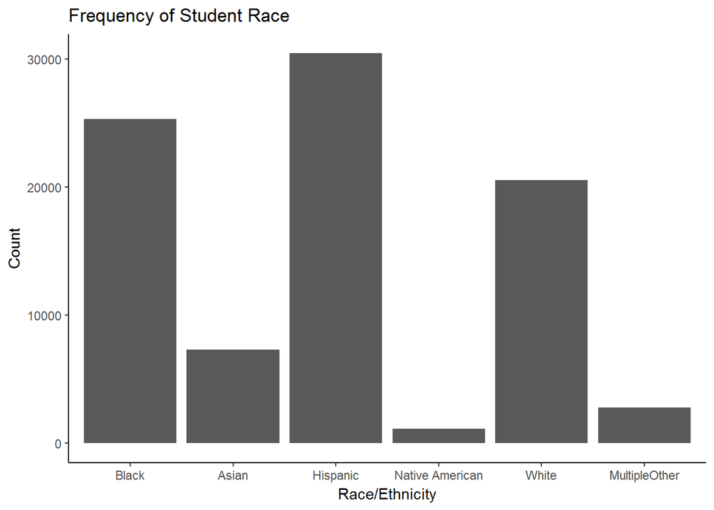

```r
library(ggplot2) # the best R library for plotting

qplot(stuatt$race_ethnicity,geom='bar') +
  theme_classic() + labs(x = 'Race/Ethnicity', y = 'Count',
                    title = "Frequency of Student Race")
```

*2. Create a variable indicating how many unique values `race_ethnicity` assumes for each student called `nvals_race`.*

```r
# Create a variable indicating how many unique values `race_ethnicity` takes
# for each student

stuatt <- stuatt %>% group_by(sid) %>%
  mutate(nvals_race = nvals(race_ethnicity))

table(stuatt$nvals_race)
```

```
    1     2     3
87176   328    30
```

*3. Create a variable that shows how many unique values `race_ethnicity` assumes for each student and `school_year`. Name this variable `nvals_race_yr`. Tabulate the variable and browse the relevant data.*

```r
# Create a variable that shows how many unique values `race_ethnicity`
# assumes for each student and school year.

stuatt <- stuatt %>% group_by(sid, school_year) %>%
  mutate(nvals_race_yr = nvals(race_ethnicity))

#Make a table
table(stuatt$nvals_race_yr)
```

```
    1     2
87528     6
```

```r
# Browse the results
stuatt %>% select(sid, school_year, race_ethnicity, nvals_race, nvals_race_yr) %>%
  filter(nvals_race_yr > 1)
```

```
Source: local data frame [6 x 5]
Groups: sid, school_year [3]

    sid school_year race_ethnicity nvals_race nvals_race_yr
  <dbl>       <dbl>         <fctr>      <int>         <int>
1     3        2006       Hispanic          2             2
2     3        2006          Black          2             2
3  8552        2006          Asian          2             2
4  8552        2006          White          2             2
5 11382        2005       Hispanic          2             2
6 11382        2005  MultipleOther          2             2
```

4. If more than one race is reported in the same school_year, report students as multiracial, unless one of their reported race_ethnicity values is Hispanic. Report the student as Hispanic in that case.

```r
# Generate a temporary hispanic variable
# Use ifelse function to recode variable

stuatt$temp_ishispanic <- ifelse(stuatt$race_num == 3 &
                                   stuatt$nvals_race_yr > 1, 1, 0)

stuatt %>% select(sid, school_year, race_ethnicity, nvals_race,
                  nvals_race_yr, temp_ishispanic) %>%
  filter(nvals_race_yr > 1)
```

```
Source: local data frame [6 x 6]
Groups: sid, school_year [3]

    sid school_year race_ethnicity nvals_race nvals_race_yr temp_ishispanic
  <dbl>       <dbl>         <fctr>      <int>         <int>           <dbl>
1     3        2006       Hispanic          2             2               1
2     3        2006          Black          2             2               0
3  8552        2006          Asian          2             2               0
4  8552        2006          White          2             2               0
5 11382        2005       Hispanic          2             2               1
6 11382        2005  MultipleOther          2             2               0
```

```r
# Take the maximum value of temp_ishispanic by student by school_year
# This is creating a variable indicating if the student was ever
# listed as hispanic in a given school year

stuatt %<>% group_by(sid, school_year) %>%
  mutate(ishispanic = max(temp_ishispanic, na.rm=TRUE))

stuatt %>% select(sid, school_year, race_ethnicity, nvals_race, nvals_race_yr,
                  temp_ishispanic, ishispanic) %>%
  filter(nvals_race_yr > 1)
```

```
Source: local data frame [6 x 7]
Groups: sid, school_year [3]

    sid school_year race_ethnicity nvals_race nvals_race_yr temp_ishispanic ishispanic
  <dbl>       <dbl>         <fctr>      <int>         <int>           <dbl>      <dbl>
1     3        2006       Hispanic          2             2               1          1
2     3        2006          Black          2             2               0          1
3  8552        2006          Asian          2             2               0          0
4  8552        2006          White          2             2               0          0
5 11382        2005       Hispanic          2             2               1          1
6 11382        2005  MultipleOther          2             2               0          1
```

```r
# Replace hispanic values
stuatt$race_num[stuatt$nvals_race_yr > 1 & stuatt$ishispanic == 1] <- 3
stuatt$race_ethnicity[stuatt$nvals_race_yr > 1 & stuatt$ishispanic == 1] <- "Hispanic"
stuatt$race_num[stuatt$nvals_race_yr > 1 & stuatt$ishispanic != 1] <- 6
stuatt$race_ethnicity[stuatt$nvals_race_yr > 1 & stuatt$ishispanic != 1] <- "MultipleOther"

# Drop the temporary variables
stuatt <- select(stuatt, -ishispanic, -temp_ishispanic)

# Drop the duplicates resulting from fixing student with different race_ethnicity
# within a school year

# bind_rows allows us to bind two data frames with the same columns together
# The first data.frame will be all rows where the student-school_year race
# is consistent
# The second data.frame is all rows where student race varies by school_year,
# but we have corrected it and drop all duplicated rows using the distinct
# command

#NROW 87534
stuatt <- bind_rows(stuatt %>% filter(nvals_race_yr < 2),
                    stuatt %>% filter(nvals_race_yr > 1) %>%
                      distinct(sid, school_year, race_ethnicity, .keep_all=TRUE))
stuatt <- select(stuatt, -nvals_race_yr)

# Re arrange after binding the rows
stuatt %<>% arrange(sid, school_year)
```

```r
# Before we fixed the data we had 87534 rows
# We had 3 students with 2 different races, so we had 6 rows where we needed 3
# This means we had 3 extra rows

nrow(stuatt) == 87534 - 3
```

```
[1] TRUE
```

*5 Report the modal race. If multiple modes exist for a student, report the most recent race recorded.*

```r
# Calculate the modal race for a student over time, if multiple modes exist
# report the most recent
stuatt %<>% group_by(sid) %>%
  mutate(race_mode = statamode(race_ethnicity))

# tab1 <- table(modes$race_temp,modes$nvals)
# addmargins(tab1, FUN=list(Total=sum), quiet=TRUE)

stuatt %>% filter(sid == 8552) %>%
  select(sid, school_year, race_ethnicity, nvals_race, race_mode)
```

```
Source: local data frame [4 x 5]
Groups: sid [1]

    sid school_year race_ethnicity nvals_race race_mode
  <dbl>       <dbl>         <fctr>      <int>     <chr>
1  8552        2005          White          2     White
2  8552        2006  MultipleOther          2     White
3  8552        2007          White          2     White
4  8552        2009          White          2     White
```

```r
stuatt$race_ethnicity[!is.na(stuatt$race_mode)] <- stuatt$race_mode[!is.na(stuatt$race_mode)]

stuatt %>% filter(sid == 8552) %>%
  select(sid, school_year, race_ethnicity, nvals_race, race_mode)
```

```
Source: local data frame [4 x 5]
Groups: sid [1]

    sid school_year race_ethnicity nvals_race race_mode
  <dbl>       <dbl>         <fctr>      <int>     <chr>
1  8552        2005          White          2     White
2  8552        2006          White          2     White
3  8552        2007          White          2     White
4  8552        2009          White          2     White
```

```r
# Consider cases where the mode is not unique
stuatt %>% filter(sid == 2) %>%
  select(sid, school_year, race_ethnicity, nvals_race, race_mode)
```

```
Source: local data frame [2 x 5]
Groups: sid [1]

    sid school_year race_ethnicity nvals_race race_mode
  <dbl>       <dbl>         <fctr>      <int>     <chr>
1     2        2006          White          2      <NA>
2     2        2007          Black          2      <NA>
```

```r
# Define the most recent value of race observed
stuatt %<>% group_by(sid) %>%
  mutate(race_last = race_ethnicity[school_year == max(school_year)])

stuatt %>% filter(sid == 2) %>%
  select(sid, school_year, race_ethnicity, nvals_race, race_mode, race_last)
```

```
Source: local data frame [2 x 6]
Groups: sid [1]

    sid school_year race_ethnicity nvals_race race_mode race_last
  <dbl>       <dbl>         <fctr>      <int>     <chr>    <fctr>
1     2        2006          White          2      <NA>     Black
2     2        2007          Black          2      <NA>     Black
```

```r
stuatt$race_ethnicity[is.na(stuatt$race_mode)] <- stuatt$race_last[is.na(stuatt$race_mode)]

stuatt %>% filter(sid %in% c(8552, 2)) %>%
  select(sid, school_year, race_ethnicity)
```

```
Source: local data frame [6 x 3]
Groups: sid [2]

    sid school_year race_ethnicity
  <dbl>       <dbl>         <fctr>
1     2        2006          Black
2     2        2007          Black
3  8552        2005          White
4  8552        2006          White
5  8552        2007          White
6  8552        2009          White
```

```r
# Drop temporary variables
stuatt %<>% select(-nvals_race, -race_mode, -race_last, -race_num)
```

```r
table(stuatt$race_ethnicity)
```

```
          Black           Asian        Hispanic Native American           White   MultipleOther
          25323            7262           30443            1132           20553            2818
```

#### Step 3

*Create consistent values for high school diploma variables.*

1. Recode the `hs_diploma_type variable` as a numeric variable and label it. Replace the string `hs_diploma_type` variable with the numeric one. Use lower numbers for more competitive diploma types.

```r
# 1. Recode the `hs_diploma_type variable` as a numeric variable and label it.
# Replace the string `hs_diploma_type` variable with the numeric one. Use lower
# numbers for more competitive diploma types.

# In R a factor variable behaves like a labeled numeric variable in Stata
# When reading the data in from a .dta file we can recover the numeric
# labels and ordering by using the `as_factor` function
stuatt$dipl_num <- as_factor(stuatt$hs_diploma_type)
```

```r
# To show the work this saves if the data has already been labeled,
# the alternative method for manually recreating this is shown below
stuatt$dipl_num <- 4
stuatt$dipl_num <- ifelse(stuatt$hs_diploma_type == "College Prep Diploma",
                          1, stuatt$dipl_num)
stuatt$dipl_num <- ifelse(stuatt$hs_diploma_type == "Standard Diploma",
                          2, stuatt$dipl_num)
stuatt$dipl_num <- ifelse(stuatt$hs_diploma_type == "Alternative Diploma",
                          3, stuatt$dipl_num)

stuatt %>% select(sid, school_year, hs_diploma, hs_diploma_date,
                  hs_diploma_type, dipl_num) %>%
  filter(sid == 16)
```

```
Source: local data frame [2 x 6]
Groups: sid [1]

    sid school_year hs_diploma hs_diploma_date      hs_diploma_type dipl_num
  <dbl>       <dbl>      <dbl>          <date>                <chr>    <dbl>
1    16        2007          1      2008-05-14     Standard Diploma        2
2    16        2008          1      2008-05-14 College Prep Diploma        1
```

```r
stuatt$hs_diploma_type <- NULL
stuatt$hs_diploma_type <- stuatt$dipl_num
stuatt$dipl_num <- NULL

stuatt %>% select(sid, school_year, hs_diploma, hs_diploma_date,
                  hs_diploma_type) %>%
  filter(sid == 16)
```

```
Source: local data frame [2 x 5]
Groups: sid [1]

    sid school_year hs_diploma hs_diploma_date hs_diploma_type
  <dbl>       <dbl>      <dbl>          <date>           <dbl>
1    16        2007          1      2008-05-14               2
2    16        2008          1      2008-05-14               1
```

```r
# Now identify the first diploma date reported
stuatt %<>% arrange(sid, hs_diploma_date)

stuatt %<>% group_by(sid) %>%
  mutate(earliest_diploma_date = min(hs_diploma_date, na.rm=TRUE))

stuatt %>% select(sid, school_year, hs_diploma, hs_diploma_date,
                  hs_diploma_type, earliest_diploma_date) %>%
  filter(sid == 16)
```

```
Source: local data frame [2 x 6]
Groups: sid [1]

    sid school_year hs_diploma hs_diploma_date hs_diploma_type earliest_diploma_date
  <dbl>       <dbl>      <dbl>          <date>           <dbl>                <date>
1    16        2007          1      2008-05-14               2            2008-05-14
2    16        2008          1      2008-05-14               1            2008-05-14
```

```r
# 3 Create a variable that shows the earliest diploma type
## This won't work because there may be ties
# stuatt %<>% group_by(sid) %>%
#  mutate(earliest_dipl_type = hs_diploma_type[hs_diploma_date==earliest_diploma_date])

stuatt %<>% group_by(sid) %>%
 mutate(earliest_dipl_type_mode = statamode(hs_diploma_type[hs_diploma_date==earliest_diploma_date]))


stuatt %>% select(sid, school_year, hs_diploma, hs_diploma_date,
                  hs_diploma_type, earliest_diploma_date, earliest_dipl_type_mode) %>% filter(sid == 16)
```

```
Source: local data frame [2 x 7]
Groups: sid [1]

    sid school_year hs_diploma hs_diploma_date hs_diploma_type earliest_diploma_date earliest_dipl_type_mode
  <dbl>       <dbl>      <dbl>          <date>           <dbl>                <date>                   <dbl>
1    16        2007          1      2008-05-14               2            2008-05-14                      NA
2    16        2008          1      2008-05-14               1            2008-05-14                      NA
```

```r
#4 Create a variable that shows the number of unique diploma types recorded
# for the first diploma date

stuatt %<>% group_by(sid) %>%
 mutate(nvals_dipl_type =
          length(unique(hs_diploma_type[hs_diploma_date==earliest_diploma_date])))

stuatt %>% select(sid, school_year, hs_diploma_type, earliest_diploma_date,
                  earliest_dipl_type_mode, nvals_dipl_type) %>%
  filter(sid %in% c(16, 20, 80))
```

```
Source: local data frame [8 x 6]
Groups: sid [3]

    sid school_year hs_diploma_type earliest_diploma_date earliest_dipl_type_mode nvals_dipl_type
  <dbl>       <dbl>           <dbl>                <date>                   <dbl>           <int>
1    16        2007               2            2008-05-14                      NA               2
2    16        2008               1            2008-05-14                      NA               2
3    20        2008               2            2008-05-14                      NA               2
4    20        2008               1            2008-05-14                      NA               2
5    80        2005               1            2008-05-14                       2               2
6    80        2006               2            2008-05-14                       2               2
7    80        2007               2            2008-05-14                       2               2
8    80        2008               2            2008-05-14                       2               2
```

```r
# 5. Identify the modal diploma type. If multiple modes exist for a
# student, report the diploma type in the earliest school year for
# the first diploma date

stuatt %<>% group_by(sid) %>%
  mutate(earliest_dipl_type_syear = hs_diploma_type[school_year == min(school_year)])


stuatt %>% select(sid, school_year, hs_diploma_type, earliest_diploma_date,
                  earliest_dipl_type_mode, nvals_dipl_type,
                  earliest_dipl_type_syear) %>%
  filter(sid %in% c(16, 20, 80))
```

```
Source: local data frame [8 x 7]
Groups: sid [3]

    sid school_year hs_diploma_type earliest_diploma_date earliest_dipl_type_mode nvals_dipl_type
  <dbl>       <dbl>           <dbl>                <date>                   <dbl>           <int>
1    16        2007               2            2008-05-14                      NA               2
2    16        2008               1            2008-05-14                      NA               2
3    20        2008               2            2008-05-14                      NA               2
4    20        2008               1            2008-05-14                      NA               2
5    80        2005               1            2008-05-14                       2               2
6    80        2006               2            2008-05-14                       2               2
7    80        2007               2            2008-05-14                       2               2
8    80        2008               2            2008-05-14                       2               2
# ... with 1 more variables: earliest_dipl_type_syear <dbl>
```

```r
stuatt %<>% group_by(sid) %>%
  mutate(earliest_dipl_type_syear_mode = statamode(earliest_dipl_type_syear))

stuatt %>%
  select(sid, school_year, hs_diploma_type, earliest_diploma_date,
                  earliest_dipl_type_mode, nvals_dipl_type,
                  earliest_dipl_type_syear,
         earliest_dipl_type_syear_mode) %>%
  filter(sid %in% c(16, 20, 80))
```

```
Source: local data frame [8 x 8]
Groups: sid [3]

    sid school_year hs_diploma_type earliest_diploma_date earliest_dipl_type_mode nvals_dipl_type
  <dbl>       <dbl>           <dbl>                <date>                   <dbl>           <int>
1    16        2007               2            2008-05-14                      NA               2
2    16        2008               1            2008-05-14                      NA               2
3    20        2008               2            2008-05-14                      NA               2
4    20        2008               1            2008-05-14                      NA               2
5    80        2005               1            2008-05-14                       2               2
6    80        2006               2            2008-05-14                       2               2
7    80        2007               2            2008-05-14                       2               2
8    80        2008               2            2008-05-14                       2               2
# ... with 2 more variables: earliest_dipl_type_syear <dbl>, earliest_dipl_type_syear_mode <dbl>
```

```r
# 6. If multiple diploma types were recorded for the same school year and first
# diploma date, report the most competitive diploma type

stuatt %<>% group_by(sid) %>%
  mutate(temp_most_compet = min(earliest_dipl_type_syear))

stuatt %>%
  select(sid, school_year, hs_diploma_type, earliest_diploma_date,
                  earliest_dipl_type_mode, nvals_dipl_type,
                  earliest_dipl_type_syear,
         earliest_dipl_type_syear_mode, temp_most_compet) %>%
  filter(sid %in% c(16, 20, 80)) %>% as.data.frame()
```

```
  sid school_year hs_diploma_type earliest_diploma_date earliest_dipl_type_mode nvals_dipl_type
1  16        2007               2            2008-05-14                      NA               2
2  16        2008               1            2008-05-14                      NA               2
3  20        2008               2            2008-05-14                      NA               2
4  20        2008               1            2008-05-14                      NA               2
5  80        2005               1            2008-05-14                       2               2
6  80        2006               2            2008-05-14                       2               2
7  80        2007               2            2008-05-14                       2               2
8  80        2008               2            2008-05-14                       2               2
  earliest_dipl_type_syear earliest_dipl_type_syear_mode temp_most_compet
1                        2                             2                2
2                        2                             2                2
3                        2                            NA                1
4                        1                            NA                1
5                        1                             1                1
6                        1                             1                1
7                        1                             1                1
8                        1                             1                1
```

```r
# Replace original diploma type variable starting with most specific case, and
# working backward

stuatt$nvals_dipl_type <- NULL

stuatt$hs_diploma_type[!is.na(stuatt$temp_most_compet)] <-
  stuatt$temp_most_compet[!is.na(stuatt$temp_most_compet)]

stuatt$hs_diploma_type[!is.na(stuatt$earliest_dipl_type_syear_mode)] <-
  stuatt$earliest_dipl_type_syear_mode[!is.na(stuatt$earliest_dipl_type_syear_mode)]

stuatt$hs_diploma_type[!is.na(stuatt$earliest_dipl_type_mode)] <-
  stuatt$earliest_dipl_type_mode[!is.na(stuatt$earliest_dipl_type_mode)]

stuatt %>%
    select(sid, school_year, hs_diploma_type, earliest_diploma_date,
           earliest_dipl_type_mode,
           earliest_dipl_type_syear,
           earliest_dipl_type_syear_mode, temp_most_compet) %>%
    filter(sid %in% c(16, 20, 80)) %>% as.data.frame()
```

```
  sid school_year hs_diploma_type earliest_diploma_date earliest_dipl_type_mode earliest_dipl_type_syear
1  16        2007               2            2008-05-14                      NA                        2
2  16        2008               2            2008-05-14                      NA                        2
3  20        2008               1            2008-05-14                      NA                        2
4  20        2008               1            2008-05-14                      NA                        1
5  80        2005               2            2008-05-14                       2                        1
6  80        2006               2            2008-05-14                       2                        1
7  80        2007               2            2008-05-14                       2                        1
8  80        2008               2            2008-05-14                       2                        1
  earliest_dipl_type_syear_mode temp_most_compet
1                             2                2
2                             2                2
3                            NA                1
4                            NA                1
5                             1                1
6                             1                1
7                             1                1
8                             1                1
```

```r
# 7. If there are any missing diploma types, mark these as an unknown
# diploma type

stuatt$hs_diploma_type[is.na(stuatt$hs_diploma_type) &
                         !is.na(stuatt$hs_dipoma_date)] <- 4

# 8. Finally, replace hs_diploma_date with the first hs_diploma_date

stuatt$hs_diploma_date <- stuatt$earliest_diploma_date

# 9. Make sure that diploma is set to 1 if there is a diploma date reported

stuatt$hs_diploma[!is.na(stuatt$hs_diploma_date)] <- 1

# 10. Drop all temporary variables we created

stuatt %<>% select(-earliest_diploma_date, -earliest_dipl_type_mode,
                   -earliest_dipl_type_syear, -earliest_dipl_type_syear_mode,
                   -temp_most_compet)

stuatt %>%
    select(sid, school_year, hs_diploma_type) %>%
    filter(sid %in% c(16, 20, 80)) %>% as.data.frame()
```

```
  sid school_year hs_diploma_type
1  16        2007               2
2  16        2008               2
3  20        2008               1
4  20        2008               1
5  80        2005               2
6  80        2006               2
7  80        2007               2
8  80        2008               2
```

#### Step 4: Drop any unneeded variables, drop duplicates, check the data, and save the file

```r
# Drop school year as you no longer need it
stuatt %<>% select(-school_year, -birth_date)

# Drop duplicate values

tmp <- stuatt[!duplicated(stuatt),]

# Check that the file is unique by sid

nrow(tmp) == length(unique(stuatt$sid))
```

```
[1] TRUE
```

```r
# Deduplicate

rm(tmp)
stuatt <- stuatt[!duplicated(stuatt),]

# Save the current file as Student_Attributes.rda

# save(stuatt, file = "Student_Attributes.rda")

# Clean up the workspace
rm(con, idx, tmpfileName, stuatt)
```

## Task 2: STUDENT SCHOOL YEAR

### PURPOSE

In Task 2: Student School Year, you will take the `Student_Classifications_Raw` file and generate a clean `Student_School_Year` output file that matches the specification in Identify with one observation per student and school year. To do so, you will first ensure only one grade level is assigned per student per school year. Then, you will process the free or reduced price lunch (FRPL) variable (a proxy for students’ poverty status), individualized education program (IEP) variable, English language learner (ELL) variable, and gifted variable. You will also examine the total days enrolled, days absent, and days suspended variables. The core of this task:

1. Resolve instances when students have more than one grade level in a school year
2. Keep the highest value of FR PL reported by student by school year
3. If a student has both “has IE P” and “no IE P” reported in a school year, keep “has IEP”
4. If a student has both “has ELL” and “no ELL”" reported in a school year, keep “has ELL”
5. If a student is observed as both gifted eligible and not eligible, report eligible
6. Explore `days_enrolled`, `days_absent` and `days_suspended`
7. Drop duplicate observations to make the file unique by student and school year After this, you will have a data set unique by student and school year that allows you to assign students to the appropriate ninth grade cohort in Task 3.

### HOW TO START

To begin, open the `Student_Classifications_Raw` file in Stata. If you do not have Stata, you can follow the steps of the task by looking at the instructions and data snippets we have provided.

If this is your first time attempting Task 2, start with the provided raw input file. This file teaches you SDP’s cleaning methodology and allows you to check answers from a common dataset.

```r
# Read in Stata
library(haven) # required for .dta files

# To read data from a zip file we create a connection to the path of the
# zip file
tmpfileName <- "raw/Student_Classifications_Raw.dta"
con <- unz(description = "data/raw.zip", filename = tmpfileName,
           open = "rb")
stuclass <- read_stata(con) # read data in the data subdirectory
glimpse(stuclass)
```

```
Observations: 88,260
Variables: 10
$ sid                          <dbl> 1, 1, 1, 1, 2, 2, 3, 3, 3, 4, 4, 4, 5, 5, 6, 6, 6, 7, 7, 7, 7, 7, 8, 8, 8, 8, ...
$ school_year                  <dbl> 2004, 2005, 2006, 2007, 2006, 2007, 2006, 2007, 2007, 2005, 2006, 2007, 2007, ...
$ grade_level                  <dbl> 9, 9, 10, 11, 10, 11, 10, 8, 9, 11, 10, 9, 3, 2, 8, 9, 10, 8, 9, 10, 11, 12, 7...
$ frpl                         <chr> "N", "N", "R", "R", "F", "F", "F", "F", "F", "N", "N", "N", "R", "R", "R", "R"...
$ iep                          <dbl> 0, 0, 0, 0, 0, 0, 0, 0, 0, 0, 0, 0, 0, 0, 1, 1, 1, 0, 0, 0, 0, 0, 0, 0, 0, 0, ...
$ ell                          <dbl> 0, 0, 0, 0, 0, 0, 0, 0, 0, 0, 0, 0, 0, 0, 0, 0, 0, 0, 0, 0, 0, 0, 0, 0, 0, 0, ...
$ gifted                       <dbl> 0, 0, 0, 0, 0, 0, 0, 0, 0, 0, 0, 0, 0, 0, 0, 0, 0, 0, 0, 0, 0, 0, 0, 0, 0, 0, ...
$ total_days_enrolled          <dbl> 210, 210, 210, 210, 172, 172, 228, 228, 228, 184, 184, 184, 209, 209, 214, 261...
$ total_days_absent            <dbl> 14, 6, 1, 5, 22, 57, 7, 15, 15, 7, 7, 60, 35, 35, 8, 7, 95, 16, 7, 7, 3, 17, 9...
$ days_suspended_out_of_school <dbl> 0, 0, 0, 0, 0, 2, 0, 0, 0, 0, 0, 11, 0, 0, 0, 0, 7, 0, 0, 0, 0, 0, 0, 0, 0, 0,...
```

### Step 1 Create One Consistent Grade Level for Each Student Within the Same Year

```r
# Step 1: Create one consistent grade level for each student within the same year

# Keep the highest grade_level when a student has multiple grade levels
# within the same year

# distinct values function
nvals <- function(x){
  length(unique(x))
}


varIdx <- c("sid", "school_year", "grade_level", "nvals_grade",
            "max_grade_level")

stuclass %<>% group_by(sid, school_year) %>%
  mutate(nvals_grade = nvals(grade_level),
         max_grade_level = max(grade_level))


stuclass %>% select(one_of(varIdx)) %>%
  filter(sid == 3)
```

```
Source: local data frame [3 x 5]
Groups: sid, school_year [2]

    sid school_year grade_level nvals_grade max_grade_level
  <dbl>       <dbl>       <dbl>       <int>           <dbl>
1     3        2006          10           1              10
2     3        2007           8           2               9
3     3        2007           9           2               9
```

```r
stuclass$grade_level[stuclass$nvals_grade > 1] <- stuclass$max_grade_level[stuclass$nvals_grade > 1]

stuclass %>% select(one_of(varIdx)) %>%
  filter(sid == 3)
```

```
Source: local data frame [3 x 5]
Groups: sid, school_year [2]

    sid school_year grade_level nvals_grade max_grade_level
  <dbl>       <dbl>       <dbl>       <int>           <dbl>
1     3        2006          10           1              10
2     3        2007           9           2               9
3     3        2007           9           2               9
```

```r
stuclass %<>% select(-nvals_grade, -max_grade_level)
```

Step 2: Create one consistent FRPL value for each student in the same student-year

```r
# 1. Recode raw frpl variable with string type to numeric type

stuclass$frpl_num <- NA
stuclass$frpl_num[stuclass$frpl == "N"] <- 0
stuclass$frpl_num[stuclass$frpl == "R"] <- 1
stuclass$frpl_num[stuclass$frpl == "F"] <- 2

stuclass %>% select(sid, school_year, grade_level, frpl, frpl_num) %>%
  filter(sid == 80)
```

```
Source: local data frame [5 x 5]
Groups: sid, school_year [4]

    sid school_year grade_level  frpl frpl_num
  <dbl>       <dbl>       <dbl> <chr>    <dbl>
1    80        2005           9     N        0
2    80        2005           9     R        1
3    80        2006          10     N        0
4    80        2007          11     N        0
5    80        2008          12     N        0
```

```r
stuclass$frpl <- NULL
stuclass$frpl <- stuclass$frpl_num
stuclass$frpl_num <- NULL

stuclass %>% select(sid, school_year, grade_level, frpl) %>%
  filter(sid == 80)
```

```
Source: local data frame [5 x 4]
Groups: sid, school_year [4]

    sid school_year grade_level  frpl
  <dbl>       <dbl>       <dbl> <dbl>
1    80        2005           9     0
2    80        2005           9     1
3    80        2006          10     0
4    80        2007          11     0
5    80        2008          12     0
```

```r
# 2. Ensure that frpl is consistent by sid and school_year. In cases where
#  multiple values exist, report the highest value. Follow the same procedure
#  as Step 1 for grade_level.

# Check if there are any cases where different values of frpl status are reported
#  in a year

stuclass %<>% group_by(sid, school_year) %>%
  mutate(nvals_frpl = nvals(frpl))

table(stuclass$nvals_frpl)
```

```
    1     2     3
87773   430    57
```

```r
# Report the highest value of frpl by year for each student, selecting
# free over reduced over not participating

stuclass %<>% group_by(sid, school_year) %>%
  mutate(highest_frpl = max(frpl))

stuclass$frpl <- stuclass$highest_frpl

# Label the values so they are easy to understand

# drop the temporary values we created

stuclass %<>% select(-nvals_frpl, -highest_frpl)
```

** Step 3: Create one consistent IEP value for each student within the same year. **

```r
# Follow the same procedure as Step 1 for grade_level.
# Report the highest value of iep by year for each student,
#  selecting has iep over not iep.

stuclass %<>% group_by(sid, school_year) %>%
  mutate(highest_iep = max(iep)) %>%
  ungroup() %>%
  mutate(iep = highest_iep) %>%
  select(-highest_iep)
```

```r
# /*** Step 4: Create one consistent ELL value for each student within the same year. ***/
# Follow the same procedure as Step 1 for grade_level.
# // Report the highest value of ell by year for each student, selecting is ell over not ell.
stuclass %<>% group_by(sid, school_year) %>%
  mutate(highest_ell = max(ell)) %>%
  ungroup() %>%
  mutate(ell = highest_ell) %>%
  select(-highest_ell)
```

```r
# /*** Step 5: Create one consistent gifted value for each student within the same year. ***/
# Follow the same procedure as Step 1 for grade_level.
# // Report the highest value of gifted by year for each student, selecting is enrolled in gifted program over not enrolled.

stuclass %<>% group_by(sid, school_year) %>%
  mutate(highest_gifted = max(gifted)) %>%
  ungroup() %>%
  mutate(gifted = highest_gifted) %>%
  select(-highest_gifted)
```

```r
# /**** Step 6: Drop any unneeded variables, drop duplicates, and save the file ****/
# // 1. Drop duplicate observations

stuclass <- stuclass[!duplicated(stuclass),]

# // 2. Make sure your file is now unique by student and school year

nrow(stuclass) == nvals(paste0(stuclass$sid, stuclass$school_year))
```

```
[1] TRUE
```

```r
# // 3. Save the current file as Student_School_Year.dta which you will need for Task 3.

# save(stuclass, file = "Student_School_Year.rda")

# Clean up the workspace
rm(con, tmpfileName, stuclass, varIdx)
```

## Task 3: IDENTIFYING THE NINTH-GRADE COHORT

### PURPOSE

In Task 3: Identifying the Ninth Grade Cohort, you will identify the school year students first appear in ninth grade using the clean `Student_School_Year` research file from Task 2. This essential step allows you to form student cohorts and examine longitudinal college-going outcomes.

The core of this task: 1. Flag the first school year a student enrolls in grades 9, 10, 11, or 12. 2. Identify the school year in which the student was first observed in 9th grade. 3. Impute the school year in which transfer students would have been in grade 9. 4. Replace the first_9th_school_year_observed with the correctly imputed values. After completing this task, you will have a clean Student_School_Year file that identifies first-time ninth graders. This file is used both to assemble the analysis file in Connect and to complete Task 4.

### HOW TO START

To begin, open the `Student_School_Year` file, just created in Task 2, in Stata. If you do not have Stata, you can follow the steps of the task by looking at the instructions and data snippets we have provided.If this is your first time attempting Task 3, start with the cleaned output file from Task 2. This file teaches you SDP’s cleaning methodology and allows you to check answers from a common dataset.

### DATA DESCRIPTION

The input file in this case, `Student_School_Year`, also the output from Task 2, now follows the structure of `Student_School_Year` in Identify so it is unique by `sid` and `school_year`. The aim of this task will be to create a `first_9th_school_year_observed` variable using the variables in the file.

Uniqueness: This dataset was cleaned in Task 2 and is now unique by `sid` and `school_year`.

```r
# Read in Stata
library(haven) # required for .dta f;iles

# To read data from a zip file we create a connection to the path of the
# zip file
tmpfileName <- "clean/Student_School_Year.dta"
con <- unz(description = "data/clean.zip", filename = tmpfileName,
           open = "rb")
stusy <- read_stata(con) # read data in the data subdirectory
glimpse(stusy)
```

```
Observations: 87,530
Variables: 10
$ sid                          <dbl> 1, 1, 1, 1, 2, 2, 3, 3, 4, 4, 4, 5, 6, 6, 6, 7, 7, 7, 7, 7, 8, 8, 8, 8, 9, 9, ...
$ school_year                  <dbl> 2004, 2005, 2006, 2007, 2006, 2007, 2006, 2007, 2005, 2006, 2007, 2007, 2007, ...
$ grade_level                  <dbl> 9, 9, 10, 11, 10, 11, 10, 9, 11, 10, 9, 3, 8, 9, 10, 8, 9, 10, 11, 12, 7, 8, 8...
$ frpl                         <dbl+lbl> 0, 0, 1, 1, 2, 2, 2, 2, 0, 0, 0, 1, 1, 1, 1, 0, 0, 0, 0, 0, 0, 0, 0, 0, 2,...
$ iep                          <dbl> 0, 0, 0, 0, 0, 0, 0, 0, 0, 0, 0, 0, 1, 1, 1, 0, 0, 0, 0, 0, 0, 0, 0, 0, 0, 0, ...
$ ell                          <dbl> 0, 0, 0, 0, 0, 0, 0, 0, 0, 0, 0, 0, 0, 0, 0, 0, 0, 0, 0, 0, 0, 0, 0, 0, 1, 0, ...
$ gifted                       <dbl> 0, 0, 0, 0, 0, 0, 0, 0, 0, 0, 0, 0, 0, 0, 0, 0, 0, 0, 0, 0, 0, 0, 0, 0, 0, 0, ...
$ total_days_enrolled          <dbl> 210, 210, 210, 210, 172, 172, 228, 228, 184, 184, 184, 209, 214, 261, 286, 286...
$ total_days_absent            <dbl> 14, 6, 1, 5, 22, 57, 7, 15, 7, 7, 60, 35, 8, 7, 95, 16, 7, 7, 3, 17, 9, 0, 0, ...
$ days_suspended_out_of_school <dbl> 0, 0, 0, 0, 0, 2, 0, 0, 0, 0, 11, 0, 0, 0, 7, 0, 0, 0, 0, 0, 0, 0, 0, 0, 0, 0,...
```

## - TODO -

Check on p. 35-36 of the guide, incosistency on whether observed_g indicator is unique by student, or by student-grade. I’ve coded it unique by student.

```r
# /*** Step 1: Flag the first school year a student enrolls in grades 9, 10, 11, or 12. ***/
# // Create four binary indicators to flag the first school year a student enrolls in grades 9, 10, 11, or 12.

stusy %>% filter(sid == 1) %>% select(sid, school_year, grade_level)
```

```
# A tibble: 4 × 3
    sid school_year grade_level
  <dbl>       <dbl>       <dbl>
1     1        2004           9
2     1        2005           9
3     1        2006          10
4     1        2007          11
```

```r
stusy %<>% group_by(sid, grade_level) %>%
  mutate(tmpG = ifelse(school_year == min(school_year), 1, NA),
         observed_g = 1)

stusy %>% filter(sid == 1) %>% select(sid, school_year, grade_level,
                                      tmpG, observed_g)
```

```
Source: local data frame [4 x 5]
Groups: sid, grade_level [3]

    sid school_year grade_level  tmpG observed_g
  <dbl>       <dbl>       <dbl> <dbl>      <dbl>
1     1        2004           9     1          1
2     1        2005           9    NA          1
3     1        2006          10     1          1
4     1        2007          11     1          1
```

```r
# Use tidyr to spread first_flag and observed_g out
library(tidyr)
stusy$first_flag <- stusy$grade_level


stusy <- spread(stusy, key = first_flag, value = tmpG, sep = "") %>%
  select(-one_of("first_flag3", "first_flag5", "first_flag6", "first_flag7",
                 "first_flag8", "first_flag13", "first_flag17"))

stusy$observed <- stusy$grade_level

# Fill in a 1 because we want the observed vectors to populate all values
# for a student
stusy <- spread(stusy, key = observed, value = observed_g, sep = "_") %>%
  select(-one_of("observed_3", "observed_5", "observed_6",
                 "observed_7", "observed_8", "observed_13",
                 "observed_17")) %>%
  group_by(sid) %>%
  mutate(observed_9 = max(observed_9, na.rm=TRUE),
         observed_10 = max(observed_10, na.rm=TRUE),
         observed_11 = max(observed_11, na.rm=TRUE),
         observed_12 = max(observed_12, na.rm=TRUE)) %>%
  mutate(observed_9 = ifelse(is.finite(observed_9), 1, 0),
         observed_10 = ifelse(is.finite(observed_10), 1, 0),
         observed_11 = ifelse(is.finite(observed_11), 1, 0),
         observed_12 = ifelse(is.finite(observed_12), 1, 0))

# Check how many students are identified as enrolled in grades 9, 10, 11, or 12

tmp <- stusy %>%
  select(num_range(prefix= "observed_", range = 9:12)) %>%
  distinct(.keep_all=TRUE)

table(tmp$observed_9)
```

```
    0     1
 2959 18844
```

```r
table(tmp$observed_10)
```

```
    0     1
 6590 15213
```

```r
table(tmp$observed_11)
```

```
    0     1
12510  9293
```

```r
table(tmp$observed_12)
```

```
    0     1
16277  5526
```

```r
rm(tmp)
```

** Step 2: Identify the school year in which the student was first observed in 9th grade. **

```r
# // Create a variable that lists the first school year a student is observed as enrolled in grade 9.

stusy %<>% group_by(sid) %>%
  mutate(first_9th_schyear_obs = min(school_year[grade_level == 9]))

# work around weird way R handles minimum of an empty vector

stusy$first_9th_schyear_obs[!is.finite(stusy$first_9th_schyear_obs)] <- NA

stusy %>% filter(sid == 1) %>%
  select(sid, school_year, grade_level, first_flag9, observed_9, first_9th_schyear_obs)
```

```
Source: local data frame [4 x 6]
Groups: sid [1]

    sid school_year grade_level first_flag9 observed_9 first_9th_schyear_obs
  <dbl>       <dbl>       <dbl>       <dbl>      <dbl>                 <dbl>
1     1        2004           9           1          1                  2004
2     1        2005           9          NA          1                  2004
3     1        2006          10          NA          1                  2004
4     1        2007          11          NA          1                  2004
```

```r
stusy %>% ungroup %>% distinct(sid, first_9th_schyear_obs) %>%
  select(first_9th_schyear_obs) %>% unlist %>% table
```

```
.
2004 2005 2006 2007 2008 2009
   1 4884 4405 4524 5018   12
```

```r
# Say something about missing values in the list...
```

** Step 3: Impute the school year in which transfer students would have been in grade 9. **

```r
# // Impute first_9th_school_year_observed as school_year - 1, school_year - 2, or school_year - 3 for students first observed in 10th, 11th or 12th grade as transfer-ins

stusy$first_flag10[!is.finite(stusy$first_flag10)] <- 0
stusy$first_flag11[!is.finite(stusy$first_flag11)] <- 0
stusy$first_flag12[!is.finite(stusy$first_flag12)] <- 0

stusy$tempfirst9year <- ifelse(stusy$first_flag10 == 1,
                               stusy$school_year - 1,
                               ifelse(stusy$first_flag11 == 1,
                               stusy$school_year - 2,
                               ifelse(stusy$first_flag12 == 1,
                               stusy$school_year - 3,
                               NA)))

stusy %>% filter(sid == 2) %>%
  select(sid, school_year, grade_level, first_9th_schyear_obs,
         tempfirst9year)
```

```
Source: local data frame [2 x 5]
Groups: sid [1]

    sid school_year grade_level first_9th_schyear_obs tempfirst9year
  <dbl>       <dbl>       <dbl>                 <dbl>          <dbl>
1     2        2006          10                    NA           2005
2     2        2007          11                    NA           2005
```

```r
# What is up with 2003 in the table here in Stata documentation

stusy %<>% group_by(sid) %>%
  mutate(tempfirst9year = min(tempfirst9year, na.rm=TRUE))

stusy$first_9th_schyear_obs[is.na(stusy$first_9th_schyear_obs) & !is.na(stusy$tempfirst9year)] <- stusy$tempfirst9year[is.na(stusy$first_9th_schyear_obs) & !is.na(stusy$tempfirst9year)]

stusy$tempfirst9year <- NULL

#
# stusy <- bind_rows(stusy %>% filter(observed_9 == 0),
#                    stusy %<>% filter(observed_9 == 1) %>%
#   group_by(sid) %>%
#   mutate(first_9th_schyear_obs = max(first_9th_schyear_obs))
# )
# stusy %<>% arrange(sid, school_year)


# // Review the distribution of first_9th_school_year_observed for students who transferred in grades 10-12

stusy %>% ungroup %>%
  filter(first_flag10 > 0) %>%
  filter(observed_9 == 0) %>%
  distinct(sid, first_9th_schyear_obs) %>%
  select(first_9th_schyear_obs) %>% unlist %>% table
```

```
.
2004 2005 2006 2007 2008
  16  400  321  380  444
```

```r
stusy %>% ungroup %>%
  filter(first_flag11 ==1) %>%
  filter(observed_9 == 0 & observed_10 == 0 & observed_11 == 1) %>%
  distinct(sid, first_9th_schyear_obs) %>%
  select(first_9th_schyear_obs) %>% unlist %>% table
```

```
.
2004 2005 2006 2007
   2  288  285  318
```

```r
stusy %>% ungroup %>%
  filter(first_flag12 ==1) %>%
  filter(observed_9 == 0 & observed_10 == 0 & observed_11 == 0 &
           observed_12 == 1) %>%
  distinct(sid, first_9th_schyear_obs) %>%
  select(first_9th_schyear_obs) %>% unlist %>% table
```

```
.
2004 2005 2006
   2  137  145
```

```r
# Consider max of this?
stusy %>% select(sid, school_year, grade_level,
                first_9th_schyear_obs, observed_9) %>%
 filter(sid == 3)
```

```
Source: local data frame [2 x 5]
Groups: sid [1]

    sid school_year grade_level first_9th_schyear_obs observed_9
  <dbl>       <dbl>       <dbl>                 <dbl>      <dbl>
1     3        2006          10                  2007          1
2     3        2007           9                  2007          1
```

```r
# Should this be 2005 or 2007?
```

** Step 4: Adjust the imputation of first_9th_school_year_observed for students who appear in a lower grade in a later school year. **

```r
# // 1. Flag students who are observed to be in a lower grade in a subsequent school year.

stusy %<>% arrange(sid, school_year) %>%
  group_by(sid) %>%
  mutate(grade_lag = lag(grade_level, order_by = school_year)) %>%
  mutate(grade_flag = ifelse(grade_lag > grade_level & !is.na(grade_lag > grade_level), 1, 0)) %>%
  mutate(grade_flag_max = max(grade_flag, na.rm=TRUE)) %>%
  select(-grade_lag)


stusy %>% select(sid, school_year, grade_level,
                 first_9th_schyear_obs, grade_flag, grade_flag_max) %>%
  filter(sid == 3)
```

```
Source: local data frame [2 x 6]
Groups: sid [1]

    sid school_year grade_level first_9th_schyear_obs grade_flag grade_flag_max
  <dbl>       <dbl>       <dbl>                 <dbl>      <dbl>          <dbl>
1     3        2006          10                  2007          0              1
2     3        2007           9                  2007          1              1
```

```r
# // 2. Flag the first school year in which students appear in high school grades

stusy %<>% group_by(sid) %>%
  mutate(first_9th_flag = ifelse(school_year == min(school_year[grade_level %in% c(9:12)]), 1, 0))


stusy %>% select(sid, school_year, grade_level,
                 first_9th_schyear_obs, grade_flag, grade_flag_max,
                 first_9th_flag) %>%
  filter(sid == 3)
```

```
Source: local data frame [2 x 7]
Groups: sid [1]

    sid school_year grade_level first_9th_schyear_obs grade_flag grade_flag_max first_9th_flag
  <dbl>       <dbl>       <dbl>                 <dbl>      <dbl>          <dbl>          <dbl>
1     3        2006          10                  2007          0              1              1
2     3        2007           9                  2007          1              1              0
```

```r
# // 4. Replace the first_9th_school_year_observed with the correctly imputed values.

# Need to drop NAs
stusy$temp4_first9year <- NA
stusy$temp4_first9year[stusy$grade_flag_max == 1 &
                         stusy$first_9th_flag == 1 &
                         stusy$grade_level == 10] <- stusy$school_year[stusy$grade_flag_max == 1 &
                         stusy$first_9th_flag == 1 &
                         stusy$grade_level == 10] - 1

stusy$temp4_first9year[stusy$grade_flag_max == 1 &
                         stusy$first_9th_flag == 1 &
                         stusy$grade_level == 11] <- stusy$school_year[stusy$grade_flag_max == 1 &
                         stusy$first_9th_flag == 1 &
                         stusy$grade_level == 11] - 2

stusy$temp4_first9year[stusy$grade_flag_max == 1 &
                         stusy$first_9th_flag == 1 &
                         stusy$grade_level == 12] <- stusy$school_year[stusy$grade_flag_max == 1 &
                         stusy$first_9th_flag == 1 &
                         stusy$grade_level == 12] - 3

stusy %<>% group_by(sid) %>%
  mutate(temp5_first9year = min(temp4_first9year, na.rm=TRUE))


stusy %>% select(sid, school_year, grade_level,
                 first_9th_schyear_obs, grade_flag, grade_flag_max,
                 first_9th_flag, temp4_first9year, temp5_first9year) %>%
  filter(sid == 3)
```

```
Source: local data frame [2 x 9]
Groups: sid [1]

    sid school_year grade_level first_9th_schyear_obs grade_flag grade_flag_max first_9th_flag temp4_first9year
  <dbl>       <dbl>       <dbl>                 <dbl>      <dbl>          <dbl>          <dbl>            <dbl>
1     3        2006          10                  2007          0              1              1             2005
2     3        2007           9                  2007          1              1              0               NA
# ... with 1 more variables: temp5_first9year <dbl>
```

```r
stusy$first_9th_schyear_obs[stusy$grade_flag_max == 1 &
                              !is.na(stusy$temp5_first9year)] <- stusy$temp5_first9year[stusy$grade_flag_max == 1 &
                              !is.na(stusy$temp5_first9year)]


stusy %>% ungroup %>% distinct(sid, first_9th_schyear_obs) %>%
  select(first_9th_schyear_obs) %>% unlist %>% table
```

```
.
2002 2003 2004 2005 2006 2007 2008 2009
   4    9   22 5706 5154 5217 5459   11
```

## - TODO Task 3 Slightly Different Numbers than SDP ##-

** Step 5: Keep only variables relevant to future analyses, and save the file. **

```r
# // Keep relevant variables

stusy %<>% select(sid, school_year, grade_level, frpl, iep, ell, gifted,
                  total_days_enrolled, total_days_absent,
                  days_suspended_out_of_school, first_9th_schyear_obs)

# // Save the current file as Student_School_Year_Ninth.dta.
# save “${clean}\Student_School_Year_Ninth.dta”, replace
rm(stusy)
```

## Task 4: STUDENT SCHOOL ENROLLMENT

### PURPOSE

In Task 4: Student School Enrollment, you will take the Student_School_Enrollment_Raw file and generate the Student_School_Enrollment file that matches the specification in Identify. After matching Identify, you will take your dataset a few steps further by consolidating overlapping enrollment spells and determining the last withdrawal code for each student to yield the file Student_School_Enrollment_Clean. The core of this task: 1. Create a school_start and school_end variable. 2. Remove abnormal enrollment observations with missing enrollment and withdrawal dates along with enrollment or withdrawal dates that are not in the right order. 3. Consolidate overlapping enrollments by student by school. 4. Update days_enrolled based on the consolidated enrollments using the new enrollment and withdrawal dates. 5. Determine the last withdrawal code for each student. You will use this data in later analyses to determine a student’s end of high school outcomes. After completing this, you will have a clean Student_School_Enrollment file. This process sets up our analyses for high school graduation and college enrollment and persistence outcomes.

### HOW TO START

To begin, open the Student_School_Enrollment_Raw file in Stata. If you do not have Stata, you can follow the steps of the task by looking at the instructions and data snippets we have provided. If this is your first time attempting Task 4, start with the provided input file. This file teaches you SDP’s cleaning methodology and allows you to check answers from a common dataset.

```r
# Read in Stata
library(haven) # required for .dta f;iles

# To read data from a zip file we create a connection to the path of the
# zip file
tmpfileName <- "raw/Student_School_Enrollment_Raw.dta"
con <- unz(description = "data/raw.zip", filename = tmpfileName,
           open = "rb")
stuenr <- read_stata(con) # read data in the data subdirectory
glimpse(stuenr)
```

```
Observations: 95,935
Variables: 8
$ sid                  <dbl> 1, 1, 1, 1, 1, 1, 1, 1, 2, 2, 2, 3, 3, 4, 4, 4, 4, 5, 5, 6, 6, 6, 7, 7, 7, 7, 7, 8, 8,...
$ school_year          <dbl> 2004, 2004, 2005, 2005, 2006, 2006, 2007, 2007, 2006, 2007, 2007, 2006, 2007, 2005, 20...
$ school_code          <dbl> 486, 486, 485, 486, 485, 485, 485, 485, 486, 486, 486, 480, 480, 475, 470, 470, 470, 4...
$ enrollment_date      <date> 2003-06-25, 2003-08-29, 2005-01-28, 2004-09-02, 2005-08-28, 2005-08-28, 2006-08-28, 2...
$ enrollment_code_desc <chr> "Grade 9", "Grade 9", "Grade 9", "Grade 9", "Grade 10", "Grade 10", "Grade 11", "Grade...
$ withdrawal_date      <date> 2003-07-05, 2004-06-08, 2005-06-07, 2005-02-10, 2005-08-28, 2006-06-07, 2007-06-08, N...
$ withdrawal_code_desc <chr> "Promoted End Year", "Retained in Grade", "Transfer In District", "Retained in Grade",...
$ days_enrolled        <dbl> 10, 284, 130, 161, 0, 283, 284, NaN, 282, 191, 124, 361, 361, -822, 299, 330, 85, 171,...
```

```r
# /*** Step 1: Create a school_start and school_end variable ***/
# // In this example, school start is August 1, and school end is July 31 of each school year. This may be different in your agency.

library(lubridate) # handle dates and times in R correctly

stuenr$school_start <- mdy(paste0("08", "01", stuenr$school_year-1))
stuenr$school_end <- mdy(paste0("07", "31", stuenr$school_year))

# In R we have to create a character string that we convert to a date
# Converting numerics to dates and times can introduce errors

# /*** Step 2: Remove abnormal enrollment observations. ***/
# // 1. Drop observations missing both enrollment and withdrawal dates.

stuenr %<>% filter(!is.na(enrollment_date) & !is.na(withdrawal_date))

# // 2. Drop observations with enrollment and withdrawal dates on same day.

stuenr %<>% filter(!enrollment_date == withdrawal_date & !is.na(enrollment_date))

# // 3. Drop observations with withdrawal date earlier than enrollment date.

stuenr %<>% filter(!is.na(withdrawal_date) & !withdrawal_date < enrollment_date)

# // 4. Drop observations with enrollment date after the end of the current school year.

stuenr %<>% filter(school_end > enrollment_date)

# // 5. Drop observations with enrollment date before the beginning of the current school year.

stuenr %<>% filter(school_start <= enrollment_date)

# // 6. Drop observations with withdrawal date more than one month after the end of the school year.

stuenr %<>% filter(withdrawal_date <= (school_end + 31) & !is.na(withdrawal_date))

# // 7. Check to make sure enrollment dates are in the correct school year.

table(stuenr$enrollment_date >= stuenr$school_start)
```

```
 TRUE
93772
```

```r
table(stuenr$enrollment_date <= stuenr$school_end)
```

```
 TRUE
93772
```

/*** Step 3: Consolidate overlapping enrollments by student by school. ***/

```r
# // 1. Sort enrollment spells in ascending order and then check how many overlapping enrollment spells exist for a student at the same school.


stuenr %<>% arrange(sid, school_code, enrollment_date)


stuenr %<>% group_by(sid, school_code) %>%
  mutate(lag_withdrawal_date = lag(withdrawal_date)) %>% ungroup %>%
  group_by(sid, school_code, school_year) %>%
    mutate(min_enroll_date = min(enrollment_date))

# table(stuenr$enrollment_date <= stuenr$lag_withdrawal_date &
        # !is.na(stuenr$lag_withdrawal_date))
# 682?

tmp <- stuenr %>% filter(sid == 2) %>%
  select(sid, school_year, school_code, enrollment_date,
         enrollment_code_desc, withdrawal_date, lag_withdrawal_date,
         withdrawal_code_desc, min_enroll_date)

# // 2. For overlapping observations, replace the enrollment date and enrollment code description of all but the first enrollment spell with the earliest enrollment date

stuenr$enrollment_date[stuenr$enrollment_date <= stuenr$lag_withdrawal_date &
                         !is.na(stuenr$lag_withdrawal_date)] <- stuenr$min_enroll_date[stuenr$enrollment_date <= stuenr$lag_withdrawal_date &
                         !is.na(stuenr$lag_withdrawal_date)]

stuenr %>% filter(sid == 2) %>%
  select(sid, school_year, school_code, enrollment_date,
         enrollment_code_desc, withdrawal_date,
         withdrawal_code_desc)
```

```
Source: local data frame [3 x 7]
Groups: sid, school_code, school_year [2]

    sid school_year school_code enrollment_date enrollment_code_desc withdrawal_date withdrawal_code_desc
  <dbl>       <dbl>       <dbl>          <date>                <chr>          <date>                <chr>
1     2        2006         486      2005-08-27             Grade 10      2006-06-05    Promoted End Year
2     2        2007         486      2006-08-29             Grade 11      2007-03-08    Retained in Grade
3     2        2007         486      2006-08-29             Grade 11      2007-06-05    Promoted End Year
```

**// 3. Replace the withdrawal date and withdrawal code description of the earliest enrollment spell with the latest withdrawal date.**

```r
# // Sort the data first so that latest withdrawal
# information appears as the first record.

stuenr %<>% arrange(sid, school_code, enrollment_date, withdrawal_date)

stuenr %>% filter(sid == 2) %>%
  select(sid, school_year, school_code, enrollment_date,
         enrollment_code_desc, withdrawal_date,
         withdrawal_code_desc)
```

```
Source: local data frame [3 x 7]
Groups: sid, school_code, school_year [2]

    sid school_year school_code enrollment_date enrollment_code_desc withdrawal_date withdrawal_code_desc
  <dbl>       <dbl>       <dbl>          <date>                <chr>          <date>                <chr>
1     2        2006         486      2005-08-27             Grade 10      2006-06-05    Promoted End Year
2     2        2007         486      2006-08-29             Grade 11      2007-03-08    Retained in Grade
3     2        2007         486      2006-08-29             Grade 11      2007-06-05    Promoted End Year
```

```r
# // Replace withdrawal_date
# // Replace withdrawal_code_description

stuenr %<>% group_by(sid, school_code, enrollment_date) %>%
  mutate(withdrawal_date = last(withdrawal_date),
         withdrawal_code_desc = last(withdrawal_code_desc))
```

** Step 4: Update days_enrolled based on the consolidated enrollments using the new enrollment and withdrawal dates. **

```r
stuenr$days_enrolled <- stuenr$withdrawal_date - stuenr$enrollment_date

stuenr %>% filter(sid == 2) %>%
  select(sid, school_year, school_code, enrollment_date,
         enrollment_code_desc, withdrawal_date,
         withdrawal_code_desc, days_enrolled)
```

```
Source: local data frame [3 x 8]
Groups: sid, school_code, enrollment_date [2]

    sid school_year school_code enrollment_date enrollment_code_desc withdrawal_date withdrawal_code_desc days_enrolled
  <dbl>       <dbl>       <dbl>          <date>                <chr>          <date>                <chr>        <time>
1     2        2006         486      2005-08-27             Grade 10      2006-06-05    Promoted End Year      282 days
2     2        2007         486      2006-08-29             Grade 11      2007-06-05    Promoted End Year      280 days
3     2        2007         486      2006-08-29             Grade 11      2007-06-05    Promoted End Year      280 days
```

** Step 5: Determine the last withdrawal code for each student. You will use this data in later analyses to determine a student’s end of high school outcomes. **

```r
stuenr %<>% arrange(sid, withdrawal_date)

stuenr %>% filter(sid == 16) %>%
  select(sid, school_year, school_code, enrollment_date,
         enrollment_code_desc, withdrawal_date,
         withdrawal_code_desc)
```

```
Source: local data frame [2 x 7]
Groups: sid, school_code, enrollment_date [2]

    sid school_year school_code enrollment_date enrollment_code_desc withdrawal_date   withdrawal_code_desc
  <dbl>       <dbl>       <dbl>          <date>                <chr>          <date>                  <chr>
1    16        2007         450      2007-01-07             Grade 11      2007-05-22      Promoted End Year
2    16        2008         450      2007-08-20             Grade 12      2008-05-28 Graduated with Diploma
```

```r
# p.46 withdrawal date wrong in table, or needs to be updated

stuenr %<>% group_by(sid) %>%
  mutate(last_withdrawal_reason = last(withdrawal_code_desc))

stuenr %>% filter(sid == 16) %>%
  select(sid, school_year, school_code, enrollment_date,
         enrollment_code_desc, withdrawal_date,
         withdrawal_code_desc, last_withdrawal_reason)
```

```
Source: local data frame [2 x 8]
Groups: sid [1]

    sid school_year school_code enrollment_date enrollment_code_desc withdrawal_date   withdrawal_code_desc
  <dbl>       <dbl>       <dbl>          <date>                <chr>          <date>                  <chr>
1    16        2007         450      2007-01-07             Grade 11      2007-05-22      Promoted End Year
2    16        2008         450      2007-08-20             Grade 12      2008-05-28 Graduated with Diploma
# ... with 1 more variables: last_withdrawal_reason <chr>
```

** Step 6: Drop any unneeded variables, drop duplicates, and save the file **

```r
# // 1. Drop duplicate records

stuenr %<>% select(-min_enroll_date, -lag_withdrawal_date)

stuenr <- ungroup(stuenr) %>% distinct(sid, school_year, school_code,
                                    enrollment_date, .keep_all = TRUE)

# // 2. Confirm that file is unique by student, school_year, school_code, and enrollment_date

nvals(paste0(stuenr$sid, stuenr$school_year, stuenr$school_code,
             stuenr$enrollment_date)) == nrow(stuenr)
```

```
[1] TRUE
```

```r
# // 3. Save the current file as Student_School_Enrollment_Clean
# save “${clean}\Student_School_Enrollment_Clean.dta”, replace
# save(stuenr, file = "clean/Student_School_Enrollment_Clean.rda")
rm(tmp, stuenr); gc()
```

```
          used (Mb) gc trigger (Mb) max used (Mb)
Ncells  662189 35.4    1770749 94.6  1770749 94.6
Vcells 1016741  7.8    6520768 49.8 10188701 77.8
```

### DATA DESCRIPTION

The input file, Student_Test_Scores, follows the structure of Student_Test_Scores in Identify so it is unique by sid, test_code, and test_date. The aim of this task will be to create three separate clean output files, Prior_Achievement, SAT, and ACT, that report only one test score per student. This means that for eight grade prior achievement duplicates of the same test taken in the same and different years will need to be resolved. Also any duplicates of SAT or ACT scores will need to be resolved as well.

Prior Achievement (8th grade state test scores), Ideally, state test data in its raw form is unique by sid, test_subject, grade_level, and school_year. However, some students re-take the same test for the same grade in the same year. To fix this, you will make the 8th grade test score data in Student_Test_Scores unique by sid, test_subject, grade_level, and school_ year by removing any same year repeat test taking instances. Then, you will manipulate the data so tests for different subjects in the same grade_level fall on the same row so the data is unique by sid, test_subject, and grade_level. As a final step, if a student took the same test in different years (e.g. by repeating a grade), you will take the earliest instance. The data will finally be unique by sid and is considered a clean file and ready to be incorporated into the analysis file in Connect.

SAT Ideally, SAT test data in its raw form is unique by sid. However, some students re-take the SAT. To fix this, you will take the data unique by sid, test_subject, and test_date and reshape it so the data will finally be unique by sid and is considered a clean file and ready to be incorporated into the analysis file in Connect.

ACT Ideally, ACT test data in its raw form is unique by sid. However, some students re-take the ACT. To fix this, you will take the data unique by sid, test_subject, and test_date and reshape it so the data will finally be unique by sid and is considered a clean file and ready to be incorporated into the analysis file in Connect.

** Part I: Clean Prior Achievement Scores **

```r
# Read in Stata
library(haven) # required for .dta f;iles


# // 0. Load the Student_Test_Scores data file.
# To read data from a zip file we create a connection to the path of the
# zip file
tmpfileName <- "raw/Student_Test_Scores.dta"
con <- unz(description = "data/raw.zip", filename = tmpfileName,
           open = "rb")
stutest <- read_stata(con) # read data in the data subdirectory
glimpse(stutest)
```

```
Observations: 100,705
Variables: 10
$ sid                    <dbl> 6, 6, 7, 7, 7, 7, 7, 7, 8, 8, 8, 8, 9, 9, 9, 9, 10, 10, 10, 10, 10, 10, 10, 14, 14, ...
$ test_type              <chr> "State", "State", "State", "State", "State", "State", "State", "State", "State", "St...
$ school_year            <dbl> 2007, 2007, 2004, 2004, 2005, 2005, 2007, 2007, 2005, 2005, 2006, 2006, 2004, 2004, ...
$ test_date              <date> 2007-04-15, 2007-04-15, 2004-04-15, 2004-04-15, 2005-04-15, 2005-04-15, 2007-04-15,...
$ grade_level            <dbl> 8, 8, 8, 8, 9, 9, 10, 10, 8, 8, 8, 8, 7, 7, 8, 8, NaN, 8, 8, 9, 9, 10, 10, 6, 6, 7, ...
$ test_subject           <dbl+lbl> 1, 2, 1, 2, 1, 2, 1, 2, 1, 2, 1, 2, 1, 2, 1, 2, 7, 1, 2, 1, 2, 1, 2, 1, 2, 1, 2,...
$ scaled_score           <dbl> 726, 678, 722, 728, 851, 729, 609, 616, 698, 779, 754, 676, 734, 756, 702, 717, 14, ...
$ performance_level      <dbl> 2, 2, 2, 2, 2, 2, 2, 2, 2, 3, 2, 2, 2, 2, 2, 2, NaN, 2, 2, 2, 3, 1, 1, 3, 3, 4, 4, 3...
$ performance_level_desc <chr> "On the Way to Proficient", "On the Way to Proficient", "On the Way to Proficient", ...
$ raw_score              <dbl> 35, 31, 40, 36, 59, 41, 18, 19, 35, 46, 40, 32, 36, 43, 36, 35, NaN, 37, 38, 54, 50,...
```

```r
# Convert to R style
stutest$test_subject <- as_factor(stutest$test_subject)
stutest$test_subject <- tolower(as.character(stutest$test_subject))
```

```r
# // 1. Keep only the variables you need and limit the sample to state test scores in 8th grade.


statetest <- stutest %>%
            select(sid, test_type, test_subject, school_year,
                   grade_level, scaled_score, raw_score, test_date) %>%
    filter(test_type == "State" & grade_level == 8)

# Leave the original stutest, we will come back to this later. In R
# we can keep multiple datasets open in the workset at the same time.

# // 2. Clean up raw and scaled scores.
# // Change raw and scaled scores to missing if zero.

for(var in c("raw_score", "scaled_score")){
  statetest[, var][statetest[,var] == 0] <- NA
}

# //Drop observations missing both a raw and scaled test score.

statetest %<>% filter(!is.na(raw_score) | !is.na(scaled_score))

# 3. Identify same-year repeat test takers and take the highest test score.
# For ties in scores, take the last date tested
statetest %<>% arrange(sid, test_subject,
                       grade_level, school_year, scaled_score)

statetest %>% filter(sid == 595) %>%
  select(sid, test_type, school_year, test_date, grade_level,
         test_subject, scaled_score, raw_score)
```

```
# A tibble: 3 × 8
    sid test_type school_year  test_date grade_level test_subject scaled_score raw_score
  <dbl>     <chr>       <dbl>     <date>       <dbl>        <chr>        <dbl>     <dbl>
1   595     State        2007 2007-04-15           8          ela          789        49
2   595     State        2007 2007-04-15           8          ela          799        50
3   595     State        2007 2007-04-15           8         math          770        45
```

```r
statetest %<>% group_by(sid, test_subject, school_year, grade_level) %>%
  mutate(keep_flag = scaled_score == max(scaled_score) &
           test_date == max(test_date)) %>%
  ungroup %>%
  filter(keep_flag) %>%
  select(-keep_flag)

statetest %>% filter(sid == 595) %>%
  select(sid, test_type, school_year, test_date, grade_level,
         test_subject, scaled_score, raw_score)
```

```
# A tibble: 2 × 8
    sid test_type school_year  test_date grade_level test_subject scaled_score raw_score
  <dbl>     <chr>       <dbl>     <date>       <dbl>        <chr>        <dbl>     <dbl>
1   595     State        2007 2007-04-15           8          ela          799        50
2   595     State        2007 2007-04-15           8         math          770        45
```

```r
# // Verify that each student has only one state test in a
# subject in a school year.

statetest %>% distinct(sid, test_subject, grade_level, school_year) %>%
  nrow == nrow(statetest)
```

```
[1] TRUE
```

```r
# // 4. Reshape the data so math and ELA tests appear on the same row.

statetest <- reshape(as.data.frame(statetest),
               v.names = c("raw_score", "scaled_score"),
               timevar = c("test_subject"),
               idvar = c("sid", "test_type", "test_date",
                         "school_year", "grade_level"),
               direction = "wide",
               sep = "_")

# // 5. Compute standardized test scores with mean 0 and standard deviation 1.

statetest$scaled_math_std <- scale(statetest$scaled_score_math)
statetest$scaled_ela_std <- scale(statetest$scaled_score_ela)


# // 6. Identify different-year repeat test takers and take the earliest test score.
#
# // First process ELA scores
# preserve
# drop *_math*
# drop if scaled_score_ela==.
# // Keep only the earliest instance in which the student
# took the test
# sort sid grade_level school_year
# drop if sid==sid[_n-1] & grade_level==grade_
# level[_n-1] & school_year>= school_year[_n-1] & scaled_
# score_ela[_n-1]!=.
# bys sid: gen count=_n
# tab count
# drop count
# // Save the ela_scores as a tempfile to be merged on
# tempfile ela_scores
# save `ela_scores’
# restore
#
# // Next process math scores
# drop *_ela*
# drop if scaled_score_math==.
# // Keep only the earliest instance in which the student took the test
# sort sid grade_level school_year
# drop if sid==sid[_n-1] & grade_ level==grade_level[_n-1] &
# school_year>= school_year[_n-1] & scaled_score_math[_n-1]!=.
# bys sid: gen count=_n
# tab count
# drop count
# // Merge the ela_scores tempfile onto the math scores
# merge 1:1 sid using `ela_scores’, nogen

statetest %<>% group_by(sid) %>%
  mutate(keep_flag = test_date == min(test_date)) %>%
  filter(keep_flag) %>% select(-keep_flag)

# Not sure in R we need to process these separately at all!
```

```r
# // 7. Verify that each student has only one state test, and drop unneeded variables.

nrow(statetest) == nvals(statetest$sid)
```

```
[1] TRUE
```

```r
statetest %<>% select(-test_date, -test_type)

# // 8. Generate composite scaled and standardized scores that average ELA and math scores.

statetest$scaled_score_composite <- (statetest$scaled_score_ela + statetest$scaled_score_math) /2

statetest$scaled_score_composite_std <- (statetest$scaled_math_std + statetest$scaled_ela_std) /2

# // 9. Save the current file as Prior_Achievement.dta.

statetest %<>% arrange(sid, school_year, grade_level) %>%
  select(sid, school_year, grade_level, raw_score_math, raw_score_ela,
         scaled_score_math, scaled_score_ela, scaled_score_composite,
         scaled_math_std, scaled_ela_std, scaled_score_composite_std)

# save “${clean}/Prior_Achievement.dta”, replace
```

** Part II: Clean SAT Scores **

```r
# // 1. Keep only the variables and limit the sample to SAT.
sattest <- stutest %>% filter(test_type == "SAT")

sattest %<>% select(sid, test_subject, test_date, scaled_score)
# // 2. Drop duplicate observations and any observations missing test scores.

sattest %<>% distinct()
sattest %<>% filter(!is.na(scaled_score))

# // 3. Reshape the data so that math, ELA, and writing scores appear on one row by student and test date.

sattest <- reshape(as.data.frame(sattest),
               v.names = c("scaled_score"),
               timevar = c("test_subject"),
               idvar = c("sid", "test_date"),
               direction = "wide",
               sep = "_")

# Rename for convenience
names(sattest) <- c("sid", "sat_test_date", "sat_math_score",
                    "sat_verbal_score", "sat_writing_score")

sattest %<>% arrange(sid, sat_test_date)
# // 4. Identify repeat test takers and take the earliest test score.

sattest %<>% group_by(sid) %>%
  mutate(keep_flag = sat_test_date == min(sat_test_date)) %>%
  filter(keep_flag) %>% select(-keep_flag)

# // Verify that the file is now unique by student.

nrow(sattest) == nvals(sattest$sid)
```

```
[1] TRUE
```

```r
# // 5. Verify that test scores from the component subjects are not missing and generate total scores.

table(!is.na(sattest$sat_math_score) & !is.na(sattest$sat_verbal_score))
```

```
TRUE
 271
```

```r
sattest$sat_total_score <- sattest$sat_math_score + sattest$sat_verbal_score

table(!is.na(sattest$sat_math_score) & !is.na(sattest$sat_verbal_score) &
        !is.na(sattest$sat_writing_score))
```

```
TRUE
 271
```

```r
sattest$sat_total_score_plus_writing <- sattest$sat_math_score +
  sattest$sat_verbal_score + sattest$sat_writing_score

# // 6. Save the current file as SAT.dta.
```

** Part III: Clean ACT Scores **

```r
# // 1. Keep only the variables you need and limit the sample to ACT.

acttest <- stutest %>% filter(test_type == "ACT")
acttest %<>% select(sid, test_subject, test_date, scaled_score)

# // 2. Identify repeat test takers and take the earliest test score.

acttest %<>% group_by(sid) %>%
  mutate(keep_flag = test_date == min(test_date)) %>%
  filter(keep_flag) %>% select(-keep_flag)

# // 3. Keep and rename the relevant variables.
acttest %>% select(sid, test_date, scaled_score)
```

```
Source: local data frame [2,544 x 3]
Groups: sid [2,544]

     sid  test_date scaled_score
   <dbl>     <date>        <dbl>
1     10 2008-04-06           14
2     16 2008-02-07           17
3     30 2008-04-06           17
4     38 2008-02-07           19
5     40 2008-04-06           29
6     67 2008-04-06           16
7     73 2008-02-07           13
8     74 2007-10-07           28
9     77 2008-04-06           20
10    80 2008-04-06           18
# ... with 2,534 more rows
```

```r
names(acttest) <- c("sid", "act_test_date", "act_composite_score")

# // Verify that the file is now unique by student.
nrow(acttest) == nvals(acttest$sid)
```

```
[1] TRUE
```

```r
# // 4. Save the current file as ACT.dta.
rm(stutest, acttest, sattest, statetest)
```

## Task 6: STUDENT CLASS ENROLLMENT

### PURPOSE

In Task 6: Student Class Enrollment, you will take the Class_Raw file and the Student_Class_Enrollment file to create the Student_Class_Enrollment_ Merged file that combines these two files together. The combined file will identify a unique observation by student and class id. To obtain this file, you will first clean the Class_Raw file to identify core courses in math and ELA based on the course description variable and match the specification in Identify. This will make the class file unique by class id. Second, you will merge the Class file and the Student Class Enrollment file and make it unique by student id and class id. The core of this task: 1. Using the Class file: a. Drop incomplete observations b. Flag core math and English courses based on the course description 2. Merging the Student Class Enrollment file: a. Merge the Class file onto the Student_Class_Enrollment_Raw file b. Evaluate course marks and drop courses with no record of completion c. Evaluate course enrollment so that each student has only one enrollment record for a course The Student_Class_Enrollment_Merged file will be used in Connect to create on-track indicators for students. On-track indicators explore year-byyear academic progress towards high school graduation and college readiness. For instance, using course credit and course grade information, one might ask what percent of students earn the minimum number of credits in their core courses to satisfy agency graduation requirements?

### HOW TO START

To begin, open the Class_Raw file in Stata. This file contains data linking students to teachers. If you do not have Stata, you can follow the steps of the task by looking at the instructions and data snippets we have provided. In the second part of this task, you will then use the Student_Class_Enrollment file. If this is your first time attempting Task 6, start with the provided input file. This file teaches you SDP’s cleaning methodology and allows you to check answers from a common dataset.

### DATA DESCRIPTION FOR RAW FILE

The input file, Class_Raw, varies from Class in Identify in a number of key ways. Most importantly, the data is not unique by cid as shown in Identify. For instance, there may be more than one course description that describes the same course. Also, a tid is not included as it is not required for the questions later asked in this toolkit. Support for a Class file with tid will come with the Human Capital version of the toolkit. The aim of this task then is to eliminate any duplicate course code descriptions and match the Class file in Identify in its structure and uniqueness so it is unique by cid alone.

```r
# Read in Stata
library(haven) # required for .dta f;iles

# To read data from a zip file we create a connection to the path of the
# zip file
tmpfileName <- "raw/Class_Raw.dta"
con <- unz(description = "data/raw.zip", filename = tmpfileName,
           open = "rb")
classRaw <- read_stata(con) # read data in the data subdirectory
glimpse(classRaw)
```

```
Observations: 135,969
Variables: 8
$ cid                 <dbl> 541631401, 432349312, 802451252, 831688206, 34366305, 208062771, 31066135, 479293568, 3...
$ credits_possible    <dbl> 0.5, 0.5, 0.5, 0.5, 0.5, 0.5, 3.0, 0.5, 0.5, 0.5, 0.5, 0.5, 0.0, 1.0, 1.0, 0.5, 0.5, 0....
$ school_year         <dbl> 2007, 2005, 2007, 2009, 2007, 2008, 2008, 2008, 2008, 2008, 2008, 2007, 2007, 2008, 200...
$ school_code         <dbl> NaN, NaN, NaN, NaN, NaN, NaN, NaN, NaN, NaN, NaN, NaN, NaN, NaN, NaN, NaN, NaN, NaN, Na...
$ section_code        <dbl> NaN, NaN, NaN, NaN, NaN, NaN, NaN, NaN, NaN, NaN, NaN, NaN, NaN, NaN, NaN, NaN, NaN, Na...
$ instructional_level <dbl> NaN, NaN, NaN, NaN, NaN, NaN, NaN, NaN, NaN, NaN, NaN, NaN, NaN, NaN, NaN, NaN, NaN, Na...
$ course_code_desc    <chr> "ELECTIVE II", "ELECTIVE II", "ELECTIVE II", "ELECTIVE II", "ELECTIVE II", "ELECTIVE II...
$ course_code         <dbl> NaN, NaN, NaN, NaN, NaN, NaN, NaN, NaN, NaN, NaN, NaN, NaN, NaN, NaN, NaN, NaN, NaN, Na...
```

```r
# TODO - File is named incorrectly on p.59
tmpfileName <- "raw/Student_Class_Enrollment.dta"
con <- unz(description = "data/raw.zip", filename = tmpfileName,
           open = "rb")
stuclass <- read_stata(con) # read data in the data subdirectory
glimpse(stuclass)
```

```
Observations: 1,010,819
Variables: 8
$ sid                   <dbl> 13281, 18950, 18950, 17817, 4739, 4739, 6737, 4897, 19940, 1809, 2675, 2737, 7709, 94...
$ cid                   <dbl> 227008230, 488826242, 441147758, 64721603, 592975099, 986162419, 479629938, 333323200...
$ class_enrollment_date <date> 2006-08-13, 2007-08-13, 2007-08-13, 2005-08-12, 2005-08-12, 2005-08-12, 2005-08-12, ...
$ class_withdrawal_date <date> 2007-07-01, 2008-06-30, 2008-06-30, 2006-07-01, 2006-07-01, 2006-07-01, 2006-07-01, ...
$ marking_period        <chr> "S2", "S1", "S2", "S2", "Q4", "Q3", "S2", "S2", "S1", "S2", "S1", "S1", "S2", "S1", "...
$ final_grade_mark      <chr> "B-", "A", "A", "D", "C", "D", "A-", "C+", "F", "B+", "F", "B", "F", "A-", "C-", "C",...
$ final_grade_mark_num  <dbl> 2.7, 4.0, 4.0, 1.0, 2.0, 1.0, 3.7, 2.3, 0.0, 3.3, 0.0, 3.0, 0.0, 3.7, 1.9, 2.0, 1.0, ...
$ credits_earned        <dbl> 0.5, 0.5, 0.5, 1.0, 0.5, 0.5, 0.5, 0.5, 0.0, 0.5, 0.0, 0.5, 0.0, 0.5, 0.5, 0.5, 0.5, ...
```

** Part I: Clean the Class file **

```r
# // 1. Identify the critical variables that identify a class.

local_ids <- c("cid", "school_year", "school_code", "section_code",
                     "course_code")

# // 2. Drop the observations where any of the critical variables are missing
classRaw %<>%
  filter(complete.cases(.[, local_ids]))
```

** Step 1: Flag core math and English courses. **

```r
# // Note that agencies may have varying consistency in course
# names and use different criteria to identify a core course
# vs an elective.
# // In some cases, other criteria may have to be applied to
# identify core courses (e.g. the department the course is
# listed in, or length of the course.)
# // We provide a simplified version of the cleaning process
# for the class file: work within your agency to determine the
# best criteria.

# // 1. Tabulate course names
table(classRaw$course_code_desc)
```

```
     ALGEBRA   ALGEBRA II     CALCULUS   ELECTIVE I  ELECTIVE II ELECTIVE III  ELECTIVE IV       ENG 10   ENGLISH 09
        6202           21          218        27468        23679        23702        32184          101         7799
  ENGLISH 10   ENGLISH 11   ENGLISH 12    ENGLISH 9         GEOM     GEOMETRY    OTHER ELA   OTHER MATH   STATISTICS
         177          418          287         7913         2444         2409          151          310           68
TRIGONOMETRY
          44
```

```r
# // 2. Flag math courses based on the tabulation results
# // Generate a flag variable

classRaw$math_flag <- NA

# // Use the regexm function to identify course names that contain common word stems, but slightly different spellings, e.g.
# Algebra I and Algebra-I

# In R the patterns need to not have spaces in the grep command
# The spaces will be matched
# | = OR
# grep does partial matching
# grpl returns TRUE/FALSE, as.numeric converts this to 1/0
classRaw$math_flag <- as.numeric(grepl("GEOM|ALGEBRA|MATH|STAT|CALC|TRIG",
                                        classRaw$course_code_desc))
# // Check the results of flagging your variables

table(classRaw$course_code_desc, classRaw$math_flag)
```

```
                   0     1
  ALGEBRA          0  6202
  ALGEBRA II       0    21
  CALCULUS         0   218
  ELECTIVE I   27468     0
  ELECTIVE II  23679     0
  ELECTIVE III 23702     0
  ELECTIVE IV  32184     0
  ENG 10         101     0
  ENGLISH 09    7799     0
  ENGLISH 10     177     0
  ENGLISH 11     418     0
  ENGLISH 12     287     0
  ENGLISH 9     7913     0
  GEOM             0  2444
  GEOMETRY         0  2409
  OTHER ELA      151     0
  OTHER MATH       0   310
  STATISTICS       0    68
  TRIGONOMETRY     0    44
```

```r
# // 3. Repeat this process for flagging ELA courses

classRaw$ela_flag <- NA

# In R the patterns need to not have spaces in the grep command
# The spaces will be matched
# | = OR
# grep does partial matching
# grpl returns TRUE/FALSE, as.numeric converts this to 1/0
classRaw$ela_flag <- as.numeric(grepl("ENG|ELA",
                                        classRaw$course_code_desc))
# // Check the results of flagging your variables

table(classRaw$course_code_desc, classRaw$ela_flag)
```

```
                   0     1
  ALGEBRA       6202     0
  ALGEBRA II      21     0
  CALCULUS       218     0
  ELECTIVE I   27468     0
  ELECTIVE II  23679     0
  ELECTIVE III 23702     0
  ELECTIVE IV  32184     0
  ENG 10           0   101
  ENGLISH 09       0  7799
  ENGLISH 10       0   177
  ENGLISH 11       0   418
  ENGLISH 12       0   287
  ENGLISH 9        0  7913
  GEOM          2444     0
  GEOMETRY      2409     0
  OTHER ELA        0   151
  OTHER MATH     310     0
  STATISTICS      68     0
  TRIGONOMETRY    44     0
```

*** Step 3: Drop any unneeded variables, drop duplicates, and save the temporary file **

```r
# // 1. Drop the course_code_desc, as it is no longer needed.

classRaw %<>% select(-course_code_desc)
classRaw %<>% distinct()

# // 2. Verify that the data is unique by cid, and also unique by school year, school code, section code and course code.
nrow(classRaw) == nvals(classRaw$cid)
```

```
[1] TRUE
```

```r
classRaw %>% distinct(school_year, school_code,
                      section_code, course_code) %>%
  nrow == nrow(classRaw)
```

```
[1] TRUE
```

** Part II: Clean the Student_Class_Enrollment file. **

** Step 0: Load the Student_Class_Enrollment data file. **

** Step 1: Merge on the temporary Class file you saved earlier to the Student_Class_Enrollment file **

```r
# Merging is fun
# keep only files merged from both files
stuclass <- inner_join(stuclass, classRaw, by = "cid")

# /*** Step 2: Evaluate course marks. ***/


table(stuclass$final_grade_mark, stuclass$credits_possible)
```

```
            0    0.1  0.125   0.13   0.17    0.2   0.25    0.3   0.33  0.333   0.34   0.35    0.4    0.5   0.58   0.65
            0      0      0      0      0      0      0      0      0      0      0      0      0      7      0      0
  A      3168      1      3      2      1      2   2176      2      4     18      0      0      2 184776      0      1
  A-      397      0      0      0      0      0    654      0      1     25      0      0      0  84078      2      0
  A+      591      0      1      0      0      0    884      3      0      1      0      0      0  56697      0      0
  B       577      0      2      1      2      0    898      0      2     32      0      1      0 127798      0      0
  B-      131      0      0      0      0      0    340      0      0      8      0      0      0  65004      0      0
  B+      235      0      0      0      0      0    440      0      0     23      0      0      0  53348      3      0
  C       311      0      1      1      3      0    466      0      3     12      1      0      1  93813      2      0
  C-       66      0      0      0      0      0    160      0      0      2      0      0      0  46522      0      0
  C+       69      0      0      1      0      0    182      0      0      5      0      0      0  40178      0      0
  D       157      0      0      1      0      0    209      0      1      2      0      0      0  55659      1      0
  D-       33      0      0      0      0      0     75      0      0      0      0      0      0  32917      0      0
  D+       25      0      0      0      0      0     67      0      0      2      0      0      0  19732      0      0
  DF        0      0      0      0      0      0      0      0      0      0      0      0      0      5      0      0
  F       304      3      1      0      0      0    308      0      0      0      0      0      0  89928      0      0
  NGPA   3773      0      0      0      0      0    107      0      0      1      0      0      0   9670      0      0
  P      4942      1      1      0      0      0    870      0      0      0      0      0      0  10976      0      0

         0.75    0.9      1    1.2    1.5   1.67    1.8      2      3      5    130
            0      0      0      0      0      0      0      0      0      0      0
  A         4      0   3347      4    125      1      1      1      0      0      1
  A-        0      0   1153      0     27      0      1      1      0      0      0
  A+        1      0    634      0     15      0      0      2      0      0      0
  B         2      1   2329      2     39      1      0      1      0      0      0
  B-        0      0   1033      0      9      0      0      1      0      0      0
  B+        0      0    874      0      9      0      0      1      1      0      0
  C         0      0   1672      0     37      0      1      2      0      0      0
  C-        0      0    786      0      5      0      0      0      0      0      0
  C+        0      0    669      0      5      0      0      0      0      1      0
  D         1      0    925      1      7      0      0      0      1      4      0
  D-        0      0    510      0      3      0      0      0      0      0      0
  D+        0      0    356      0      0      0      0      0      0      1      0
  DF        0      0      0      0      0      0      0      0      0      0      0
  F         0      0   1284      0     24      0      0      0      1      2      0
  NGPA      0      0    163      0     12      0      0      0      0      0      0
  P         0      0    396      0      2      0      0      0      0      0      0
```

```r
table(stuclass$final_grade_mark, stuclass$final_grade_mark_num)
```

```
            0    0.4    0.6    0.7      1    1.3    1.9      2    2.3    2.7      3    3.3    3.7      4    4.3
            0      0      0      0      0      0      0      0      0      0      0      0      0      0      0
  A         0      0      0      0      0      0      0      0      0      0      0      0      0 193640      0
  A-        0      0      0      0      0      0      0      0      0      0      0      0  86339      0      0
  A+        0      0      0      0      0      0      0      0      0      0      0      0      0      0  58829
  B         0      0      0      0      0      0      0      0      0      0 131688      0      0      0      0
  B-        0      0      0      0      0      0      0      0      0  66526      0      0      0      0      0
  B+        0      0      0      0      0      0      0      0      0      0      0  54934      0      0      0
  C         0      0      0      0      0      0      0  96326      0      0      0      0      0      0      0
  C-        0      0      0      0      0      0  47541      0      0      0      0      0      0      0      0
  C+        0      0      0      0      0      0      0      0  41110      0      0      0      0      0      0
  D         0      0      0      0  56969      0      0      0      0      0      0      0      0      0      0
  D-        0      0      0  33538      0      0      0      0      0      0      0      0      0      0      0
  D+        0      0      0      0      0  20183      0      0      0      0      0      0      0      0      0
  DF        0      0      5      0      0      0      0      0      0      0      0      0      0      0      0
  F     91855      0      0      0      0      0      0      0      0      0      0      0      0      0      0
  NGPA      0    687      0      0      0      0      0      0      0      0      0      0      0      0      0
  P         0      0      0      0      0      0      0      0      0      0      0      0      0      0      0
```

```r
#
# // Some letter marks (NGPA and P) indicate that they do not count toward GPA, so you may leave the numeric mark as missing.

# ** Step 3: Evaluate course completion. **
# // Drop observations that have no record of course completion

stuclass %<>% filter(!is.na(final_grade_mark) &
                       !is.na(final_grade_mark_num) &
                       !is.na(credits_earned))

# ** Step 4: Evaluate course enrollment. **
# // Fix cases where a student has multiple observations for the same course with the same year and marking period (i.e. with overlapping enrollment dates)


# // 1. Remove enrollment and withdrawal dates that are not in the current school year.


library(lubridate) # handle dates and times in R correctly

stuclass$school_start <- mdy(paste0("08", "01", stuclass$school_year-1))
stuclass$school_end <- mdy(paste0("07", "31", stuclass$school_year))

stuclass$class_enrollment_date[stuclass$class_enrollment_date <
                                 stuclass$school_start |
                                 stuclass$class_enrollment_date >
                                 stuclass$school_end] <- NA
stuclass$class_withdrawal_date[stuclass$class_withdrawal_date <
                                 stuclass$school_start |
                                 stuclass$class_withdrawal_date >
                                 stuclass$school_end] <- NA


stuclass %<>% select(-school_start, -school_end)


stuclass %>% filter(sid == 2251 & cid == 78150780) %>%
  select(sid, cid, school_code, school_year, class_enrollment_date,
         class_withdrawal_date)
```

```
# A tibble: 4 × 6
    sid      cid school_code school_year class_enrollment_date class_withdrawal_date
  <dbl>    <dbl>       <dbl>       <dbl>                <date>                <date>
1  2251 78150780         540        2006            2005-08-12            2005-08-17
2  2251 78150780         540        2006            2005-09-21            2005-11-02
3  2251 78150780         540        2006            2005-12-23                  <NA>
4  2251 78150780         540        2006            2005-09-13            2005-08-27
```

```r
# // 2. Identify the variables that identify a course

local_ids <- c("sid", "cid", "school_year", "marking_period")

# // 3. Populate all enrollments with the earliest enrollment date

# use group_by_ to pass character values to dplyr
stuclass %<>% ungroup %>%
  group_by(sid, cid, school_year, marking_period) %>%
  arrange(class_enrollment_date) %>%
  mutate(first_enroll = min(class_enrollment_date, na.rm=TRUE))


# There is a bug here in the enrollment date
# If you use group_by_ and mutate without the underscore
# in a pipe, and then calculate max or min of a date, you
# get the wrong time

stuclass$class_enrollment_date <- stuclass$first_enroll
stuclass %<>% select(-first_enroll)

stuclass %>% ungroup %>% filter(sid == 2251 & cid == 78150780) %>%
  select(sid, cid, school_code, school_year, class_enrollment_date,
         class_withdrawal_date)
```

```
# A tibble: 4 × 6
    sid      cid school_code school_year class_enrollment_date class_withdrawal_date
  <dbl>    <dbl>       <dbl>       <dbl>                <date>                <date>
1  2251 78150780         540        2006            2005-08-12            2005-08-17
2  2251 78150780         540        2006            2005-08-12            2005-08-27
3  2251 78150780         540        2006            2005-08-12            2005-11-02
4  2251 78150780         540        2006            2005-08-12                  <NA>
```

```r
# // 4. Populate all enrollments with the latest withdrawal date

stuclass %<>% ungroup %>%
  arrange(sid, cid, school_year, marking_period, class_withdrawal_date) %>%
  group_by(sid, cid, school_year, marking_period) %>%
  mutate(last_withdraw = max(class_withdrawal_date, na.rm=TRUE))

stuclass %>% ungroup %>% filter(sid == 2251 & cid == 78150780) %>%
  select(sid, cid, class_enrollment_date,
         class_withdrawal_date, last_withdraw)
```

```
# A tibble: 4 × 5
    sid      cid class_enrollment_date class_withdrawal_date last_withdraw
  <dbl>    <dbl>                <date>                <date>        <date>
1  2251 78150780            2005-08-12            2005-08-17    2005-11-02
2  2251 78150780            2005-08-12            2005-08-27    2005-11-02
3  2251 78150780            2005-08-12            2005-11-02    2005-11-02
4  2251 78150780            2005-08-12                  <NA>    2005-11-02
```

```r
stuclass$class_withdrawal_date <- stuclass$last_withdraw
stuclass$last_withdraw <- NULL

stuclass %>% ungroup %>% filter(sid == 2251 & cid == 78150780) %>%
  select(sid, cid, school_code, school_year, marking_period,
         section_code, class_enrollment_date,
         class_withdrawal_date, class_withdrawal_date)
```

```
# A tibble: 4 × 8
    sid      cid school_code school_year marking_period section_code class_enrollment_date class_withdrawal_date
  <dbl>    <dbl>       <dbl>       <dbl>          <chr>        <dbl>                <date>                <date>
1  2251 78150780         540        2006             S1            7            2005-08-12            2005-11-02
2  2251 78150780         540        2006             S1            7            2005-08-12            2005-11-02
3  2251 78150780         540        2006             S1            7            2005-08-12            2005-11-02
4  2251 78150780         540        2006             S1            7            2005-08-12            2005-11-02
```

** Step 5: Drop any unneeded variables, drop duplicates, and save the file **

```r
# // 1. Drop duplicate values

stuclass %<>% ungroup %>% distinct()

# // 2. Verify that the file is unique by sid and cid

nrow(stuclass) == nvals(paste0(stuclass$sid, stuclass$cid, sep ="_"))
```

```
[1] TRUE
```

```r
# // 3. Order the variables

stuclass %<>% select(sid, cid, school_year, school_code, course_code,
                     marking_period, section_code, instructional_level,
                     credits_possible, math_flag, ela_flag,
                     class_enrollment_date, class_withdrawal_date,
                     final_grade_mark, final_grade_mark_num,
                     credits_earned)
# // 4. Sort the data

stuclass %<>% ungroup() %>%
  arrange(sid, school_year, marking_period, cid)

# // 5. Save the current file as Student_Class_Enrollment_Merged.dta.
```

## Task 7 STUDENT NSC ENROLLMENT

### PURPOSE

In Task 7: Student NSC Enrollment, you will take the Student_NSC_Enrollment file that matches the specification in Identify and produce a Student_ NSC_Enrollment_Indicators file that includes some of the first college enrollment indicators you will need for further analysis. College enrollment data is obtained from the National Student Clearninghouse (NSC). NSC matches students from a file your agency sends, including student id, student name, high school from where the student graduated, graduation date, and some other variables. For more information on the NSC matching process and requirements, visit http://www.studentclearinghouse.org/high_schools/studenttracker The core of this task: 1. Rename the variables typically returned by NSC 2. Format the date values 3. Standardize the variables that reflect the type of college the student enrolls in 4. Create a college graduation indicator 5. Interpret the college enrollment status 6. Identify the first college the student attended After this task, you will merge the Student_NSC_Indicators file onto the college-going analysis file from Connect. You will use this file and the high school graduation variables you will also create in Connect to then to generate further college-going variables, such as variables that indicating if a student enrolled in college the fall after graduation, enrolled in college a year after graduation, and persisted through subsequent years of college.

### HOW TO START

To begin, open the Student_NSC_Enrollment file in Stata. This file contains data on college enrollment and persistence for students in your agency. If you do not have Stata, you can follow the steps of the task by looking at the instructions and data snippets we have provided. If this is your first time attempting Task 7, start with the provided input file. This file teaches you SDP’s cleaning methodology and allows you to check answers from a common dataset.

### DATA DESCRIPTION

The input file, Student_NSC_Enrollment, follows the structure of Student_NSC_Enrollment in Identify so it is unique by sid, college_code_branch, enrollment_ begin, and enrollment_end. This usually equates to a semester. Though the exact structure of the data you receive from NSC may vary, it will likely look something like this. The aim of this task then is to become familiar with the NSC data and start building college enrollment outcomes that will be expanded upon in Connect.

** Step 0: Load the Student_NSC_Enrollment data file. **

```r
# Read in Stata
library(haven) # required for .dta files

# To read data from a zip file we create a connection to the path of the
# zip file
tmpfileName <- "raw/Student_NSC_Enrollment.dta"
con <- unz(description = "data/raw.zip", filename = tmpfileName,
           open = "rb")
stunsc <- read_stata(con) # read data in the data subdirectory
glimpse(stunsc)
```

```
Observations: 11,985
Variables: 15
$ sid                 <dbl> 7, 10, 10, 10, 10, 10, 16, 20, 24, 24, 30, 33, 33, 33, 33, 33, 34, 36, 36, 38, 38, 38, ...
$ record_found_yn     <chr> "N", "Y", "Y", "Y", "Y", "Y", "Y", "Y", "Y", "Y", "Y", "Y", "Y", "Y", "Y", "Y", "N", "Y...
$ enrollment_begin    <dbl> NaN, 20100109, 20090523, 20090110, 20090829, 20080830, 20090829, 20080819, 20100109, 20...
$ enrollment_end      <dbl> NaN, 20100503, 20090814, 20090505, 20091215, 20081216, 20091215, 20081012, 20100503, 20...
$ college_code_branch <chr> "", "746460-00", "746460-00", "746460-00", "746460-00", "746460-00", "860457-00", "4928...
$ college_name        <chr> "", "COMMUNITY COLLEGE 400", "COMMUNITY COLLEGE 400", "COMMUNITY COLLEGE 400", "COMMUNI...
$ college_state       <chr> "", "FL", "FL", "FL", "FL", "FL", "MA", "FL", "NY", "NY", "IL", "TX", "MA", "MA", "MA",...
$ yr2_yr4             <chr> "", "2-year", "2-year", "2-year", "2-year", "2-year", "2-year", "4-year", "2-year", "2-...
$ public_private      <chr> "", "Public", "Public", "Public", "Public", "Public", "Public", "Private", "Public", "P...
$ enrollment_status   <chr> "", "L", "L", "H", "L", "F", "F", "W", "F", "F", "F", "L", "F", "F", "F", "F", "", "F",...
$ graduated           <chr> "N", "N", "N", "N", "N", "N", "N", "N", "N", "N", "N", "N", "N", "N", "N", "N", "N", "N...
$ graduation_date     <dbl> NaN, NaN, NaN, NaN, NaN, NaN, NaN, NaN, NaN, NaN, NaN, NaN, NaN, NaN, NaN, NaN, NaN, Na...
$ college_sequence    <dbl> NaN, 1, 1, 1, 1, 1, 1, 1, 1, 1, 1, 2, 1, 1, 1, 1, NaN, 1, 1, 1, 1, 1, 1, 1, 1, 1, 1, 2,...
$ degree_title        <chr> "", "", "", "", "", "", "", "", "", "", "", "", "", "", "", "", "", "", "", "", "", "",...
$ major               <chr> "", "", "", "", "", "", "", "", "", "", "", "", "", "", "", "", "", "", "", "", "", "",...
```

```r
# // 1. Rename variables to indicate that they are NSC variables.

names(stunsc) <- c("sid", "n_record_found_yn", "n_enrollment_begin",
                   "n_enrollment_end", "n_college_opeid",
                   "n_college_name", "college_state","yr2_yr4",
                   "public_private", "n_enrollment_status",
                   "graduated", "n_degree_date",
                   "n_enrl_sequence", "degree_title", "major")

# // 2. Format the date values as dates.
library(lubridate)

stunsc <- as.data.frame(stunsc)
for(i in c("n_enrollment_begin", "n_enrollment_end",
           "n_degree_date")){
  stunsc[, i] <- lubridate::ymd(as.character(stunsc[, i]))
  }

stunsc %>% filter(sid == 13047) %>%
  select(sid, n_record_found_yn, n_enrollment_begin,
         n_enrollment_end, n_college_name, yr2_yr4,
         public_private, n_enrollment_status, graduated)
```

```
    sid n_record_found_yn n_enrollment_begin n_enrollment_end      n_college_name yr2_yr4 public_private
1 13047                 Y         2009-01-10       2009-05-05 B COMMUNITY COLLEGE  2-year         Public
2 13047                 Y         2008-08-30       2008-12-17     UNIVERSITY OF B  4-year        Private
3 13047                 Y         2009-08-29       2009-12-15 B COMMUNITY COLLEGE  2-year         Public
4 13047                 Y         2008-08-30       2008-12-16 B COMMUNITY COLLEGE  2-year         Public
  n_enrollment_status graduated
1                   F         N
2                   F         N
3                   H         N
4                   H         N
```

```r
### Drop missing
# stunsc %<>% filter(stunsc$college_state != "")


# // 3. Standardize types of college by:
# // 2-year and 4-year college

stunsc$n_college_4yr <- ifelse(stunsc$yr2_yr4 == "4-year", 1, 0)
stunsc$n_college_2yr <- ifelse(stunsc$yr2_yr4 == "2-year" |
                                 stunsc$yr2_yr4 == "Less Than 2 Years",
                               1, 0)

stunsc$yr2_yr4 <- NULL

# // Public and private college
table(stunsc$public_private)
```

```
        Private  Public
   1088    2660    8237
```

```r
stunsc$n_college_public <- ifelse(stunsc$public_private == "Public", 1, 0)
stunsc$n_college_private <- ifelse(stunsc$public_private == "Private", 1, 0)
stunsc$public_private <- NULL

# // In-state and out-of-state college
table(stunsc$college_state)
```

```
       CA   FL   IL   MA   NY   TX
1088 1915 1905 1683 1865 1779 1750
```

```r
stunsc$n_college_instate <- ifelse(stunsc$college_state == "MA", 1, 0)
stunsc$n_college_outstate <- ifelse(stunsc$college_state != "MA", 1, 0)
stunsc$college_state <- NULL

# // 4. Create a college graduation indicator.
stunsc$n_degree <- ifelse(stunsc$graduated == "Y", 1, 0)
stunsc$graduated <- NULL
# // 5. Interpret enrollment status.

table(stunsc$n_enrollment_status)
```

```
        F    H    L    W
1118 8693 1350  551  273
```

```r
stunsc$n_enrl_status <- factor(stunsc$n_enrollment_status,
                               levels = c("F", "H", "L", "W",
                                          "A", "D"))
stunsc$n_enrollment_status <- NULL
```

** Step 2: Identify first college attended by type (any, 4-year and 2-year) that didn’t result in a withdrawal. **

```r
# // 1. Specify these types of college (any, 4-year, 2-year) in globals.
# global condition_any “n_college_4yr == 1 | n_college_2yr == 1”
# global condition_4yr “n_college_4yr == 1”
# global condition_2yr “n_college_2yr == 1”
# // 2. Calculate the days enrolled.

stunsc$days_enrolled <- stunsc$n_enrollment_end - stunsc$n_enrollment_begin

# // 3. Identify the first college a student enrolled in by type (any, 2-year, and 4-year).

stunsc %>% filter(sid == 13047) %>%
  select(sid, n_record_found_yn, n_enrollment_begin,
         n_enrollment_end, n_college_name,
         n_enrl_status, n_college_4yr, n_college_2yr)
```

```
    sid n_record_found_yn n_enrollment_begin n_enrollment_end      n_college_name n_enrl_status n_college_4yr
1 13047                 Y         2009-01-10       2009-05-05 B COMMUNITY COLLEGE             F             0
2 13047                 Y         2008-08-30       2008-12-17     UNIVERSITY OF B             F             1
3 13047                 Y         2009-08-29       2009-12-15 B COMMUNITY COLLEGE             H             0
4 13047                 Y         2008-08-30       2008-12-16 B COMMUNITY COLLEGE             H             0
  n_college_2yr
1             1
2             0
3             1
4             1
```

```r
stunsc %<>% group_by(sid) %>%
  mutate(flag_status = ifelse(n_enrl_status %in% c("F", "H", "L"), 1, 0))

stunsc %>% filter(sid == 13047) %>%
  select(sid, n_record_found_yn, n_enrollment_begin,
         n_enrollment_end, n_college_name,
         n_enrl_status, n_college_4yr, n_college_2yr, flag_status)
```

```
Source: local data frame [4 x 9]
Groups: sid [1]

    sid n_record_found_yn n_enrollment_begin n_enrollment_end      n_college_name n_enrl_status n_college_4yr
  <dbl>             <chr>             <date>           <date>               <chr>        <fctr>         <dbl>
1 13047                 Y         2009-01-10       2009-05-05 B COMMUNITY COLLEGE             F             0
2 13047                 Y         2008-08-30       2008-12-17     UNIVERSITY OF B             F             1
3 13047                 Y         2009-08-29       2009-12-15 B COMMUNITY COLLEGE             H             0
4 13047                 Y         2008-08-30       2008-12-16 B COMMUNITY COLLEGE             H             0
# ... with 2 more variables: n_college_2yr <dbl>, flag_status <dbl>
```

```r
stunsc %<>% group_by(sid, n_college_4yr) %>%
  mutate(first_enr_date_4yr = min(n_enrollment_begin[flag_status > 0])) %>%
  ungroup %>%
  group_by(sid, n_college_2yr) %>%
  mutate(first_enr_date_2yr = min(n_enrollment_begin[flag_status > 0])) %>%
  ungroup %>%
  group_by(sid) %>%
  mutate(first_enr_date_any = min(n_enrollment_begin[flag_status > 0]))


stunsc %>% filter(sid == 13047) %>%
  select(sid,n_enrollment_begin,
         n_enrollment_end,
         n_enrl_status, n_college_4yr, n_college_2yr, flag_status,
         first_enr_date_2yr, first_enr_date_4yr,
         first_enr_date_any) %>% as.data.frame
```

```
    sid n_enrollment_begin n_enrollment_end n_enrl_status n_college_4yr n_college_2yr flag_status first_enr_date_2yr
1 13047         2009-01-10       2009-05-05             F             0             1           1         2008-08-30
2 13047         2008-08-30       2008-12-17             F             1             0           1         2008-08-30
3 13047         2009-08-29       2009-12-15             H             0             1           1         2008-08-30
4 13047         2008-08-30       2008-12-16             H             0             1           1         2008-08-30
  first_enr_date_4yr first_enr_date_any
1         2008-08-30         2008-08-30
2         2008-08-30         2008-08-30
3         2008-08-30         2008-08-30
4         2008-08-30         2008-08-30
```

```r
stunsc %>% filter(sid == 13047) %>%
  select(sid, n_college_opeid,
         n_enrl_status, n_college_4yr, n_college_2yr, flag_status,
         first_enr_date_2yr, first_enr_date_4yr,
         first_enr_date_any) %>% as.data.frame
```

```
    sid n_college_opeid n_enrl_status n_college_4yr n_college_2yr flag_status first_enr_date_2yr first_enr_date_4yr
1 13047       164039-00             F             0             1           1         2008-08-30         2008-08-30
2 13047       416739-00             F             1             0           1         2008-08-30         2008-08-30
3 13047       164039-00             H             0             1           1         2008-08-30         2008-08-30
4 13047       164039-00             H             0             1           1         2008-08-30         2008-08-30
  first_enr_date_any
1         2008-08-30
2         2008-08-30
3         2008-08-30
4         2008-08-30
```

```r
stunsc %<>% group_by(sid) %>%
  mutate(first_college_any_opeid = n_college_opeid[first_enr_date_any == n_enrollment_begin][1],
         first_college_4yr_opeid = n_college_opeid[first_enr_date_4yr == n_enrollment_begin & n_college_4yr > 0][1],
         first_college_2yr_opeid = n_college_opeid[first_enr_date_2yr == n_enrollment_begin & n_college_2yr > 0][1]) %>%
  ungroup


# # // Get the college name and id for the first enrollment date
#
# stunsc %>% filter(sid == 13047) %>%
#   select(sid, n_college_opeid,
#          n_enrl_status, n_college_4yr, n_college_2yr,
#          first_enr_date_2yr, first_enr_date_4yr,
#          first_enr_date_any,
#          first_college_any_opeid,
#          first_college_4yr_opeid, first_college_2yr_opeid) %>% as.data.frame
#
# # // Count how many first college names and ids you got for each student
# # bys sid: egen nvals_first_college_`var’_`type’ = nvals(temp_first_college_`var’_`type’)
#
# tmp <- stunsc %>% select(sid, first_college_any_opeid,
#                          first_college_4yr_opeid, first_college_2yr_opeid)
#
# tmp <- tmp[!duplicated(tmp), ]
# tmp$nunique <- apply(tmp[, 2:4], 1, function(x) length(unique(na.omit(x))))
#
# stunsc <- left_join(stunsc, tmp[, c(1,5)], "sid")
# rm(tmp); gc()
#
#
# stunsc %>% filter(nunique > 1) %>%
#   select(sid, n_enrl_status, n_college_4yr, n_college_2yr,
#          n_enrollment_begin,
#          n_college_opeid, first_college_any_opeid,
#          first_college_4yr_opeid, first_college_2yr_opeid,
#          days_enrolled) %>%
#   filter(sid == 13653) %>% as.data.frame
#




# // If a student started at multiple colleges of the same type on the same date, indicate this by replacing

# // these values with a dummy value (“>1”) for processing.
# replace temp_first_college_`var’_`type’ = “>1” if nvals_first_college_`var’_`type’ > 1 & nvals_first_college_`var’_`type’
# !=.
```

** Step 3: Drop any unneeded variables, and save the file **

```r
# // 1. Drop the unneeded variables
# drop temp* nvals* days_enrolled
# // 2. Save the current file as Student_NSC_Enrollment_Indicators
# save “${clean}\Student_NSC_Enrollment_Indicators.dta”, replace
```